# Final Project

Matthew Davis

Open-source code and data can be found at https://github.com/matthewlouisdavisBioStat/AbsolutelyStacked

Use devtools::install_github(‘matthewlouisdavisBioStat/AbsolutelyStacked’) to install.

Update to the most recent version of MachineShop from github with devtools::install_github(‘brian-j-smith/MachineShop’) before running.

# Introduction

The AbsolutelyStacked package provides software for fitting generalized linear regression models and generalized linear conditional mixed-effect regression models under custom sum and inequality constraints, as well as a full-pipeline for constructing stacked models, performing backwards base-learner selection via AIC, and providing posterior distributions for parameters of interest, all fully compatible with MachineShop.

Outcomes that can be modeled so far include (but are not limited to) Poisson regression, quasi-Poisson regression, logistic regression, probit regression, linear regression, Weibull AFT models for right-censored outcomes and categorical-logistic regression, all of which can be fit with or without random effects.

Since the primary motivation of the package was (originally) to bet on NBA games, additionally included is code to automate the pulling-and-processing of real-time NBA data, fitting stacked models, and producing posterior-predictive distributions for NBA-related outcomes. Data sets are provided for user convenience.

## Motivating Application: Gambling

### NBA Over/Unders

An over/under bet is one in the better decides whether the total number of points scored in a sports game (the sum of both teams combined) will be “over” or “under” a certain value. For example, when the Cleveland Cavaliers and the Chicago Bulls play tonight, the over/under set is 213; if the Bulls score 113, and the Cavaliers score 105, the total points scored would 218, which would be $\textit{over}$. I could decide to bet whether I think the total sum of scores will be $\textit{over}$ 213 or $\textit{under}$ 213.

The catch is, for every 10 dollar bet, one only wins 9.09 dollars if victorious, but loses all 10 dollars if wrong (10/11). The magic number comes down to 52.38%. With some math, it can be shown that with the 90.9% gain vs. 100% loss of an over/under, a bet is only worth it if the probability of the total sum of points being greater than the over/under, OR the probability of the total sum of points being less than the over/under, is greater than approximately 52.38%. For a ten dollar bet,

$$E[profit] \\
= 9.09Pr(Win) -10Pr(Lose) \\
= 9.09(.52383) - 10(1-.52383)\\
\approx 0$$

For decisions such as these, the natural probabilistic interpretation is to bet based on expectation; is our expected profit for betting positive? Bet. Is it negative? Don’t bet. Posterior-predictive distributions make decisions like these easy; some mock-code for doing so below might drive home the point.

```r
if(F){
  if(mean(posterior_predictive_draws > over_under) > .52383){
    print('bet over')
 } else if (mean(posterior_predictive_draws < over_under) > .52383){
    print('bet under')
  } else{
    print('do not bet')
  }
}
```

However, deriving a posterior-predictive distribution is not easy.

### A Prior Distribution

First, a prior distribution is needed - why not base it off of Vegas’s over/unders themselves?

Think about it. Vegas has EVERY financial incentive to guess the expected over/under as close to the true total points scored as possible. Consider a normal distribution; if they guess the `true’ mean, then there is a 50% chance of the total points being greater than the over/under, and a 50% chance less. It is not hard math to see that when betters can only win 90.9% of their bet but (at best) but have a 50% chance of losing, Vegas is all but guaranteed to profit (in actuality it’s more complicated than this, as the explicit goal is to try to set the odds as close to a point such that 50% of people will bet over and 50% of people will bet under, which guarantees profit independent of the outcome; but this ends up being centered about the true outcome anyways.)

So let’s download some historical data (I pulled from https://sportsdatabase.com/) and see how close Vegas’s over/unders were to the actual total points scored. Below is a visualization of the residuals of the log total-points-scored vs. Vegas’s log over/under from 2016-2020. A normal distribution density with standard deviation equal to the standard error of Vegas is overlayed on top of the histogram of residuals.

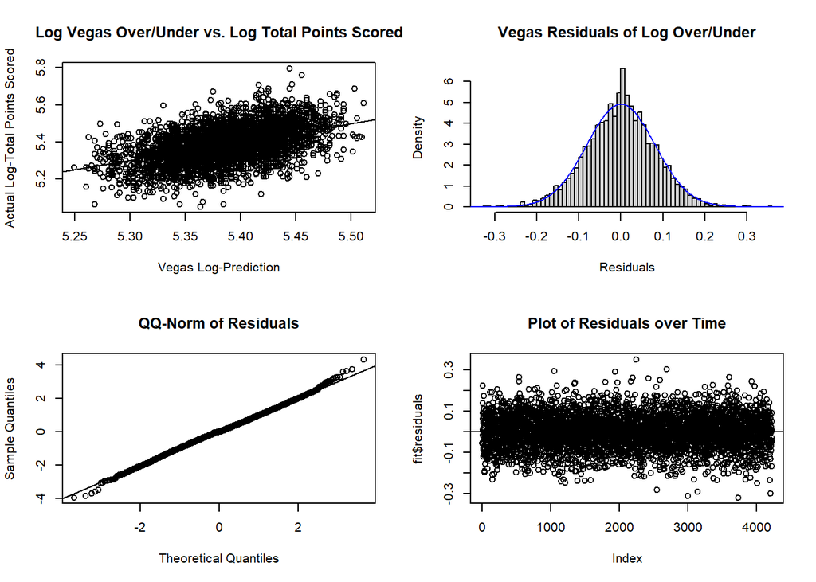

I get that nothing “actually” follows a normal distribution, but seriously…..

### Results from Last Year

I made EXACTLY $0 in profit/loss over the regular season and playoffs. My methods were much more crude (I knew much less about statistics), and I made a million and a half coding errors which probably set me back. So I’m obviously out for blood this year.

Nonetheless, after 553 games for which bets were considered, although my stacked machine learning models did not outperform Vegas’s predictions with respect to mean absolute error (MAE), leveraging Vegas’s over/under as a prior distribution AND utilizing my stacked model as a likelihood yielded a posterior distribution that beat their prior out with respect to mean absolute error.

| MAE Vegas | MAE My Stacked Model | MAE Posterior-Predictive Distribution MAP |
| --- | --- | --- |
| 14.7285714285714 | 14.8863570442134 | 14.6630766723061 |

The Vegas prior distribution beat my likelihood, but my posterior-distribution’s MAP beat Vegas.

$$\textbf{WE CAN LEVERAGE VEGAS'S SUPERIOR PERFORMANCE AGAINST THEM!!!!}$$

# AbsolutelyStacked Package

In order to bet on the NBA, I made a package that helps fit stacked models in MachineShop and automates the process of deriving posterior distributions for parameters of interest.

## Validating the glmer_constrained() function

### Description

The heart of the package is the glmer_constrained() function, which can be straightforwardly used for applications outside of stacking as well. Below, some brief simulations are shown to validate its performance.

The glmer_constrained() function fits conditional mixed-effects regression models as well as GLM models without random effects. Because prediction is prioritized, not estimation, the random effects are returned rather than marginalized over.

The basic procedure for fitting can be summarized in two steps. For more rigorous mathematical description, see “Methods in Detail”.

First, the unconstrained MLEs for fixed effects and random effect coefficients are estimated via a damped Newton-Raphson algorithm. Second, the constrained MLE estimates of fixed effects are updated through one of two possible procedures. The Rsolnp package in R provides a general non-linear programming script solnp() that can be used to directly maximize the likelihood under custom inequality constraints, and is the approach used by the StackedModel() function in MachineShop. Alternatively, the quadprog packages provides a more specialized quadratic programming script solve.QP() which only requires specification of the score and information to implement, and is wrapped in an iterative procedure. Initial values for both approaches are based on the unconstrained MLEs, which are also returned by the function.

### Simulations

In the simulations below, it is confirmed that the glmer_constrained() function returns appropriate results.

Unless otherwise noted, the true beta coefficients for all simulations below are -0.5,0, 0.5, and 1.5, and lower bounds are set as -1, -0.5, 0, and 1 respectively (which is just each coefficient minus 0.5).

The sum-constraints set on the models are such that the sum of fixed-effect coefficients (correctly) adds to 1.5.

1000 observations are generated under each condition unless otherwise noted.

Results from stacking using iterative quadratic programming (i.e. the quadprog package), vs. the more general non-linear optimizer (using the Rsolnp package) are shown, as well as output from other software when available.

#### Poisson Regression

Table continues below

|  | True Betas | Constrained MLE Rsolnp | Constrained MLE quadprog |
| --- | --- | --- | --- |
| **Beta1** | -0.5 | -0.5079 | -0.5079 |
| **Beta2** | 0 | 0.0874 | 0.0873 |
| **Beta3** | 0.5 | 0.4996 | 0.4995 |
| **Beta4** | 1.5 | 1.421 | 1.421 |

|  | Unconstrained MLE glmer_constrained | Unconstrained MLE glm() |
| --- | --- | --- |
| **Beta1** | -0.5051 | -0.5051 |
| **Beta2** | 0.0894 | 0.0894 |
| **Beta3** | 0.4904 | 0.4904 |
| **Beta4** | 1.367 | 1.367 |

#### Logistic Regression

Note, that for logit regression, the Rsolnp package returned slightly differing results than the quadprog package.

Table continues below

|  | True Betas | Constrained MLE Rsolnp | Constrained MLE quadprog |
| --- | --- | --- | --- |
| **Beta1** | -0.5 | -0.3749 | -0.3777 |
| **Beta2** | 0 | 0.0078 | 0.0064 |
| **Beta3** | 0.5 | 0.4916 | 0.4919 |
| **Beta4** | 1.5 | 1.375 | 1.379 |

|  | Unconstrained MLE glmer_constrained | Unconstrained MLE glm() |
| --- | --- | --- |
| **Beta1** | -0.3683 | -0.3683 |
| **Beta2** | 0.0361 | 0.0361 |
| **Beta3** | 0.5437 | 0.5437 |
| **Beta4** | 1.48 | 1.48 |

#### Probit Regression

Note, that for probit regression, the Rsolnp package returned very differing results than the quadprog package.

Table continues below

|  | True Betas | Constrained MLE Rsolnp | Constrained MLE quadprog |
| --- | --- | --- | --- |
| **Beta1** | -0.5 | -1 | -0.3433 |
| **Beta2** | 0 | -0.5 | -0.0121 |
| **Beta3** | 0.5 | 0.4677 | 0.46 |
| **Beta4** | 1.5 | 2.532 | 1.395 |

|  | Unconstrained MLE glmer_constrained | Unconstrained MLE glm() |
| --- | --- | --- |
| **Beta1** | -0.3116 | -0.3116 |
| **Beta2** | 0.0442 | 0.0442 |
| **Beta3** | 0.542 | 0.542 |
| **Beta4** | 1.53 | 1.53 |

#### Weibull AFT Model

Right-censored outcomes are also able to be handled via a Weibull AFT model. Below, the constraints are set such that the sum of coefficients is exactly equivalent to the sum of the coefficients returned by survreg, and lower bounds are equivalent to the minimum of the coefficients returned by survreg.

Hence, as we should expect, all constrained and unconstrained MLEs are (appropriately) in agreement.

The data set and model for this analysis is taken from Dr. Breheny’s site for my past survival course (see Accelerate Failure Times R code from https://myweb.uiowa.edu/pbreheny/7210/f19/notes.html)

Table continues below

|  | Constrained MLE Rsolnp | Constrained MLE quadprog |
| --- | --- | --- |
| **(Intercept)** | 9.809 | 9.809 |
| **trt** | 0.096 | 0.096 |
| **stage** | -0.4294 | -0.4294 |
| **hepato** | -0.2363 | -0.2363 |
| **bili** | -0.0915 | -0.0915 |

|  | Unconstrained MLE glmer_constrained | Unconstrained MLE survreg() |
| --- | --- | --- |
| **(Intercept)** | 9.809 | 9.809 |
| **trt** | 0.096 | 0.096 |
| **stage** | -0.4294 | -0.4294 |
| **hepato** | -0.2363 | -0.2363 |
| **bili** | -0.0915 | -0.0915 |

#### Linear Mixed-Effects Model with Single Random-Effect Variance Parameter

This introduces the fact that the stacked function can fit any arbitrary random effects structure coded by a Z matrix and a list of indices corresponding to which columns of the Z matrix pair with which random-variance parameter (sigma list).

Below, a simple random-intercept linear regression model is demonstrated.

Table continues below

|  | True Betas/Random Intercepts | Constrained MLE Rsolnp |
| --- | --- | --- |
| **Beta1** | -0.5 | -0.516 |
| **Beta2** | 0 | -0.0053 |
| **Beta3** | 0.5 | 0.5212 |
| **Beta4** | 1.5 | 1.5 |
| **RandInt1** | -0.3028 | -0.3739 |
| **RandInt2** | -0.5534 | -0.6694 |
| **RandInt3** | -1.568 | -1.407 |
| **RandInt4** | 0.4103 | 0.4187 |
| **RandInt5** | 0.8293 | 0.7103 |
| **RandInt6** | 0.6677 | 0.3821 |
| **RandInt7** | -3.867 | -3.947 |
| **RandInt8** | 0.3662 | 0.3163 |
| **RandInt9** | 0.5155 | 0.515 |
| **RandInt10** | 4.351 | 4.292 |

Table continues below

|  | Constrained MLE quadprog | Unconstrained MLE glmer_constrained |
| --- | --- | --- |
| **Beta1** | -0.516 | -0.499 |
| **Beta2** | -0.0053 | 0.0205 |
| **Beta3** | 0.5212 | 0.5512 |
| **Beta4** | 1.5 | 1.525 |
| **RandInt1** | -0.3739 | -0.3739 |
| **RandInt2** | -0.6694 | -0.6694 |
| **RandInt3** | -1.407 | -1.407 |
| **RandInt4** | 0.4187 | 0.4187 |
| **RandInt5** | 0.7103 | 0.7103 |
| **RandInt6** | 0.3821 | 0.3821 |
| **RandInt7** | -3.947 | -3.947 |
| **RandInt8** | 0.3163 | 0.3163 |
| **RandInt9** | 0.515 | 0.515 |
| **RandInt10** | 4.292 | 4.292 |

|  | Unconstrained MLE lmer |
| --- | --- |
| **Beta1** | -0.499 |
| **Beta2** | 0.0205 |
| **Beta3** | 0.5512 |
| **Beta4** | 1.525 |
| **RandInt1** | -0.3739 |
| **RandInt2** | -0.6695 |
| **RandInt3** | -1.407 |
| **RandInt4** | 0.4187 |
| **RandInt5** | 0.7103 |
| **RandInt6** | 0.3822 |
| **RandInt7** | -3.947 |
| **RandInt8** | 0.3164 |
| **RandInt9** | 0.515 |
| **RandInt10** | 4.292 |

#### Categorical Mixed-Effects Model with Multiple Random-Effect Variance Parameters

Unfortunately, I could not find an R package that fit conditional mixed-effects categorical regression to compare to.

For the following simulation below, there are $K = 3$ possible outcomes (although greater values of $K$ can be specified) - the way this package models categorical outcomes is by generalizing logistic regression such that the outcome, both on the probabilistic and link-function scale, can be expressed as an $N \times (K-1)$ matrix, the $p$ fixed effects and $q$ random effect coefficients take on the form of $(K-1) \times (K-1)$ diagonal matrices, and the score (gradient of the log-likelihood with respect to the parameters of interest) is a $(q+p) \times (K-1)$ matrix. Unlike the simulation for linear mixed-effects, an additional layer of complexity for this problem was added such that there are 5 unique random-effect variance parameters for 10 random effects (2 random effects per variance component).

For the Newton-Raphson procedure, I treat X and Z as “design matrices”, whose columns are not vectors but instead $N \times (K-1)$ matrices. The outcome of interest $Y$ is a “vector” with elements as $1 \times (K-1)$ vectors, not scalars. The fixed effect and random effect coefficients are “vectors” as well with elements $(K-1) \times (K-1)$ diagonal matrices. In reality, any mathematical object I’ve denoted with quotations above is coded as a list in R. Specialized functions in the package generalize certain types of matrix and vector operations for these lists, one of which is shown below.

While unconstrained MLE estimates for the coefficient “weight-matrices” may be heterogeneous across diagonals, for a sensical stacked model, the weights are ultimately formulated as a simple $p \times 1$ vector of scalars (what are we going to do, weight the probability of single-overtime returned by a neural net differently than a probability of a double-overtime returned by the same neural net? This is possible but too complicated for me to think about).

Since there are many more parameters involved with this simulation compared to previous, the sample size was increased to 10000 instead of just 1000. For reference, the time it took to fit the models are printed out as well.

Finally, since the procedure for fitting categorical mixed-effects models slightly differs from other link functions, explicit code used for fitting is shown for boilerplate reference.

```r
## generalizes matrix multiplication for A %*% b when A and b are lists,
## the elements of which are conformable 1 x (K-1) and (K-1) x (K-1) matrices
`%**%` <- function(A,b){
  list <- (lapply(1:length(A),function(j){
    A[[j]] %*% b[[j]]
  }))
  sapply(1:ncol(list[[1]]),function(j){
    rowSums(sapply(list,function(l)l[,j]))
  })
}
```

```r
set.seed(52246)
#### Simulate Data Parameters ####
## N observations total
N <- 10000
## design "matrix" for fixed effects
Xt <- lapply(1:4,function(i)cbind(runif(N,-1,1),runif(N,-1,1)))
## design "matrix" for random effects
Zt_temp <- lapply(1:2,function(i)kronk(lapply(1:10,function(i){
  cbind(rep(1,N/10))
})))
Zt <- lapply(1:10,function(i)cbind(rep(0,N),rep(0,N)))
for(i in 1:10){
  Zt[[i]] <- cbind(Zt_temp[[1]][,i],
                   Zt_temp[[2]][,i])
}
## true "vector" of fixed effects
Bt <- list(diag(-.5,2),
           diag(0,2),
           diag(.5,2),
           diag(1.5,2))
## true random-effect variance components
unique_sds <- rep(rgamma(5,1,1),each = 2)
## True "vector" of random effects
Ut <- lapply(1:10,function(i)diag(rnorm(2,mean=0,sd = unique_sds[i])))
## sigma_list
sigma_list <- list()
for(i in 1:5){
  sigma_list[[paste0("sigma_",i)]] <- c(seq(1,10,by = 2)[i],seq(2,10,by = 2)[i])
  names(sigma_list[[paste0("sigma_",i)]]) <- rep(paste0("sigma_",i),2)
}
```

```r
softmax <- function(x)exp(x)/(1+sum(exp(x)))
## Simulate Link Function Parameter
Etat <- Xt %**% Bt + Zt %**% Ut
## Back-Transform to the Mean of the Response
Mut <- t(apply(Etat,1,softmax))
## Generate Outcome of Interest
Yt <- t(apply(Mut,1,function(mu)rmultinom(1,1,prob = c(1-sum(mu),mu))))
```

The outcome variable is an $N \times K$ matrix. The first column (similar to logistic regression) is dropped for modelling purposes.

```r
head(Yt)
```

```
##      [,1] [,2] [,3]
## [1,]    0    0    1
## [2,]    1    0    0
## [3,]    0    0    1
## [4,]    1    0    0
## [5,]    0    1    0
## [6,]    0    0    1
```

Thus, the linear link-function is an $N \times (K-1)$ matrix.

```
##            [,1]       [,2]
## [1,] -0.3054628  0.3307284
## [2,] -1.7940154 -0.4327205
## [3,] -1.9061219 -1.7058473
## [4,] -0.3233923 -0.8572723
## [5,] -1.7133148 -0.1542680
## [6,] -0.2274850  1.2604407
```

The design matrix for fixed and random effects are both expressed as list of matrices (i.e. the columns of the design matrix become lists, and the elements of the design matrix become vectors).

```r
lapply(Xt,head)
```

```
## [[1]]
##             [,1]        [,2]
## [1,]  0.93750622  0.85108057
## [2,] -0.92420906 -0.22490826
## [3,] -0.15574462  0.47942872
## [4,]  0.51087827  0.32735659
## [5,]  0.43713561  0.53636405
## [6,]  0.06704836  0.01986381
##
## [[2]]
##            [,1]        [,2]
## [1,]  0.2119158 -0.99365943
## [2,]  0.3756766 -0.27012835
## [3,] -0.3863315 -0.46163218
## [4,] -0.3876168 -0.07781737
## [5,] -0.7728989  0.01052135
## [6,] -0.6282979  0.46754148
##
## [[3]]
##            [,1]       [,2]
## [1,] -0.9942377  0.3499620
## [2,] -0.5450983  0.3770338
## [3,] -0.5156269  0.2710164
## [4,]  0.3925839 -0.5617993
## [5,] -0.8627747  0.8918165
## [6,]  0.6549056  0.1717028
##
## [[4]]
##            [,1]       [,2]
## [1,]  0.9671214  0.4628659
## [2,] -0.7955318 -0.4137869
## [3,] -0.6239385 -0.9924200
## [4,]  0.3506853 -0.1997888
## [5,] -0.1820577 -0.1459887
## [6,]  0.1792396  0.8650215
```

```r
lapply(Zt,head)
```

```
## [[1]]
##      [,1] [,2]
## [1,]    1    1
## [2,]    1    1
## [3,]    1    1
## [4,]    1    1
## [5,]    1    1
## [6,]    1    1
##
## [[2]]
##      [,1] [,2]
## [1,]    0    0
## [2,]    0    0
## [3,]    0    0
## [4,]    0    0
## [5,]    0    0
## [6,]    0    0
##
## [[3]]
##      [,1] [,2]
## [1,]    0    0
## [2,]    0    0
## [3,]    0    0
## [4,]    0    0
## [5,]    0    0
## [6,]    0    0
##
## [[4]]
##      [,1] [,2]
## [1,]    0    0
## [2,]    0    0
## [3,]    0    0
## [4,]    0    0
## [5,]    0    0
## [6,]    0    0
##
## [[5]]
##      [,1] [,2]
## [1,]    0    0
## [2,]    0    0
```

[output cut: 34 more lines]

```
## [1,]    0    0
## [2,]    0    0
## [3,]    0    0
## [4,]    0    0
## [5,]    0    0
## [6,]    0    0
##
## [[10]]
##      [,1] [,2]
## [1,]    0    0
## [2,]    0    0
## [3,]    0    0
## [4,]    0    0
## [5,]    0    0
## [6,]    0    0
```

sigma_list connects the column indices (now the indices of a list) of the random effects design matrix to corresponding variance components.

```r
sigma_list
```

```
## $sigma_1
## sigma_1 sigma_1
##       1       2
##
## $sigma_2
## sigma_2 sigma_2
##       3       4
##
## $sigma_3
## sigma_3 sigma_3
##       5       6
##
## $sigma_4
## sigma_4 sigma_4
##       7       8
##
## $sigma_5
## sigma_5 sigma_5
##       9      10
```

Below, the models are fit, first using the Rsolnp and then quadprog packages to update MLE weights under constraint.

```r
#### Constrained Maximum Likelihood-Based stacking
sigmas <- rep(1,5)
names(sigmas) <- paste0("sigma_",1:5)
strt <- Sys.time()
stacked_output_solnp <- glmer_constrained(
  link_function = 'softmax',
  X = Xt,
  Y = Yt[,-1],
  Z = Zt,
  tau = 1,
  est_tau = F,
  sigmas = sigmas,
  beta_update = c(0,0,0,0),
  u_update = cbind(rep(0,10),rep(0,10)),
  lambda = 0,
  sigma_list = sigma_list,
  use_quadprog = F,
  sum_constraint = 1.5,
  lower_bound_constraint = c(-1,-.5,0,.5)
)
nd <- Sys.time()
print(nd - strt)
```

```
## Time difference of 1.046797 mins
```

```r
strt <- Sys.time()
stacked_output_qp <- glmer_constrained(
  link_function = 'softmax',
  X = Xt,
  Y = Yt[,-1],
  Z = Zt,
  tau = 1,
  est_tau = F,
  sigmas = sigmas,
  beta_update = c(0,0,0,0),
  u_update = cbind(rep(0,10),rep(0,10)),
  lambda = 0,
  sigma_list = sigma_list,
  use_quadprog = T,
  sum_constraint = 1.5,
  lower_bound_constraint = c(-1,-.5,0,.5)
)
nd <- Sys.time()
print(nd - strt)
```

```
## Time difference of 1.193572 mins
```

Even though the true stacked fixed-effects weights we want in the end are scalar values, as a side effect of fitting GLMs, the unconstrained MLEs for both fixed and random effects take on the form of diagonal matrices of dimension $K-1$, if there are $K$ possible categorical outcomes, with non-homogeneous elements.

```
## [1] "True Betas vs. Unconstrained MLEs"
```

```
## [[1]]
##      TrueVal1 TrueVal2       MLE1       MLE2
## [1,]     -0.5      0.0 -0.5422808  0.0000000
## [2,]      0.0     -0.5  0.0000000 -0.5624811
##
## [[2]]
##      TrueVal1 TrueVal2       MLE1       MLE2
## [1,]        0        0 0.04245882  0.0000000
## [2,]        0        0 0.00000000 -0.0685608
##
## [[3]]
##      TrueVal1 TrueVal2      MLE1      MLE2
## [1,]      0.5      0.0 0.5455089 0.0000000
## [2,]      0.0      0.5 0.0000000 0.5595615
##
## [[4]]
##      TrueVal1 TrueVal2     MLE1    MLE2
## [1,]      1.5      0.0 1.447837 0.00000
## [2,]      0.0      1.5 0.000000 1.54778
```

```
## [1] "True Random Effects vs. BLUPs"
```

```
## [[1]]
##       TrueVal1   TrueVal2      BLUP1       BLUP2
## [1,] -0.790273  0.0000000 -0.8026697  0.00000000
## [2,]  0.000000 -0.1130111  0.0000000 -0.09625238
##
## [[2]]
##       TrueVal1   TrueVal2     BLUP1       BLUP2
## [1,] 0.2841993  0.0000000 0.2061889  0.00000000
## [2,] 0.0000000 -0.1482492 0.0000000 -0.09315494
##
## [[3]]
##       TrueVal1  TrueVal2     BLUP1     BLUP2
## [1,] 0.5485283 0.0000000 0.5652018 0.0000000
## [2,] 0.0000000 0.4026918 0.0000000 0.5428969
##
## [[4]]
##        TrueVal1   TrueVal2      BLUP1      BLUP2
## [1,] -0.2416633  0.0000000 -0.1891316  0.0000000
## [2,]  0.0000000 -0.4509127  0.0000000 -0.4405808
##
## [[5]]
##        TrueVal1  TrueVal2      BLUP1     BLUP2
## [1,] -0.2761447 0.0000000 -0.2320713 0.0000000
## [2,]  0.0000000 0.2079853  0.0000000 0.2000263
##
## [[6]]
##        TrueVal1   TrueVal2      BLUP1      BLUP2
## [1,] -0.6050487  0.0000000 -0.6789155  0.0000000
## [2,]  0.0000000 -0.6945895  0.0000000 -0.7325653
##
## [[7]]
##       TrueVal1 TrueVal2     BLUP1    BLUP2
## [1,] -2.908418 0.000000 -2.645949 0.000000
## [2,]  0.000000 1.130989  0.000000 1.054595
##
## [[8]]
##       TrueVal1  TrueVal2     BLUP1     BLUP2
## [1,] 0.9699971 0.0000000 0.9204895 0.0000000
## [2,] 0.0000000 0.5022248 0.0000000 0.4716933
##
## [[9]]
##        TrueVal1   TrueVal2      BLUP1      BLUP2
## [1,] -0.7869711  0.0000000 -0.7077972  0.0000000
## [2,]  0.0000000 -0.4019358  0.0000000 -0.4037216
##
## [[10]]
##      TrueVal1  TrueVal2    BLUP1     BLUP2
## [1,] 1.573578  0.000000 1.552072  0.000000
## [2,] 0.000000 -3.341467 0.000000 -3.476809
```

Finally, we see that the constrained weights indeed take on the form of ordinary vectors as modeled in this package, which as mentioned, makes for more sensible stacked models. Random effects remain as diagonal matrices with non-homogenous elements.

| True Betas | Constrained MLE solnp | Constrained MLE quadprog |
| --- | --- | --- |
| -0.5 | -0.4841 | -0.5516 |
| 0 | -0.07438 | -0.0105 |
| 0.5 | 0.5163 | 0.557 |
| 1.5 | 1.542 | 1.505 |

The quadratic-programming procedure had to be modified for multi-dimensional outcomes, and so it often returns slightly differing results than directly-maximizing the likelihood. See Methods in Detail.

## Code for Stacking

Despite it’s flexibility for fitting arbitrary models, the priority of glmer_constrained() is not inference, but to serve as a base for stacking.

The full wrapper below fits stacked models the way same as above, except the covariates of the design matrix are now the out-of-fold link-transformed predictions of base learners. By this, I mean a stacked model for binary outcomes would weight the $\textit{log-odds}$ returned by each base learner, for Poisson outcomes, the stacked model would weight the log-predictions returned by base-learners, for probit regression the qnorm() of base learner predictions, etc.

For models such as linear-discriminant analysis, K-nearest neighbors, or support-vector machines in which predictions are deterministic and not probabilistic, predictions are replaced by a psuedo-value (such as 0.9999 in place of 1, or 0.0001 instead of 0) so link-function transformations are possible.

With the basic description out of the way, below are functions in the package that are used for stacking.

### make_glmerStackedModel()

The make_glmerStackedModel() is essentially a wrapper for the MLModel() function of MachineShop; it creates a custom MLModel that can be used as the meta learner (or super learner) when paired with the SuperModel() function.

One may also manually specify weights for stacking without fitting; however, if one does this, random effects and unconstrained MLEs for weights will NOT be estimated.

```r
if(F){
  make_glmerStackedModel(
      link,  # link function
      incl_random_efx, # should random effects be 'predicted'?
      tau_0, # initial value (or fixed value) of exponential dispersion parameter
      est_dispersion, # should a dispsersion parameter be estimated?
      min_learners, # the minimum number of base learners to include in the stacked model
      Z, # random effects design matrix
      sigma_list, # list of Z-matrix indices corresponding to which variance components are being estimated
      use_qp, # should quadratic programming be used instead of directly maximizing the likelihood?
      fixed_weights, # are manual weights being specified?
      weights = NULL, # manually specified weights, if fixed_weights = T
      trace = T # should progress on backwards base-learner selection print to the console?
    )
}
```

### quantify_stacked_uncertainty()

Following the fitting procedure, the fit object returned by MachineShop can be directly passed into the function quantify_stacked_uncertainty() which provides posterior distributions for any dispersion parameters associated with the stacked GLM model, as well as the parameter $\sigma^2_{\hat{\eta}}$ which captures the uncertainty associated with the covariate-response relationship (this will be covered more later, also see Methods in Detail). These posterior distributions are necessary if one wishes to derive a posterior-predictive distribution using a stacked model.

This function is essentially a wrapper for rstan. The arguments passed to the function are presented below, with defaults listed explicitly

```r
if(F){
quantify_stacked_uncertainty(fit, # fit object returned by SuperModel() with make_glmerStackedModel() as the meta learner
                             chain = 2, # how many chains?
                             iter = 25000, # how many iterations per chain?
                             warmup = 1000, # how many iterations for warming up?
                             cores = parallel::detectCores()/2, # number of cores for running in parallel
                             prior_sigmaSq_etahat = paste0("inv_gamma(1,1)"), # prior distribution capturing uncertainty of covariate-response relationship
                             prior_dispersion = NULL, # the prior distribution on the exponential dispersion parameter, if desired
                             filename = NULL, # the filename to save draws to
                             return_fit = F, # should the original fitted model be returned?
                             stopImplicitCluster_option = T, # should stopImplicitCluster() be run before setting up new clusters?
                             take_a_break_first = F,  # should the computer wait 2 minutes following the fitting procedure before running stan? This may be useful if your computer (like mine) tends to crash when overwhelmed with parallelism.
                             verbose = T) # should rstan progress be printed to the console?
}
```

### stepAIC_stacked

The stepAIC_stacked function performs backwards variable selection via AIC, whereby the out-of-fold predictions of base learners are the “variables” being considered, and the out-of-fold likelihood of the stacked model is evaluated at the constrained MLES of the weights. The number of base learners is the $p$ in the $2p$ penalty term of $-2logL + 2p$. This is useful for selecting an optimal combination of base learners. AICc is implemented for linear regression in place of AIC.

This does not require additional cross-validation.

$\textbf{Note: this may not be a real AIC is because each covariate is itself a function of parameters of unknown dimension}$.

```r
if(F){
stepAIC_stacked(vars, # names of base learners
                cv_data, # cross-validated out-of-fold design matrix
                Zmodel, # random-effects design matrix
                link_func, # link function
                est_tau_model = F, # should exponential dispersion parameter be estimated?
                t_init, # initial value for exponential dispersion parameter
                s_init, # initial values for random error variance components
                b_init, # initial values for the weights
                u_init, # initial values for the random effects
                list_of_sigmas, # a list connecting which columns of the Z matrix correspond to which random-effect variance components?
                qp = F, # should quadratic programming be used (alternative to directly maximizing the constrained likelihood)
                min_num_learners, # minimum number of base learners left for when the backwards variable selection finishes
                use_fixed_weights = F, # are fixed weights being specified? Then no backwards selection is performed.
                preset_weights = NULL, # if use_fixed_weights == T, no fitting is performed and these serve as the custom stacked weights
                tr = T) # should progress on backwards variable selection be printed to the console?
}
```

### MLModel_DataPrep

While MachineShop allows a user to pair a single model with a data-preparation step, it does not allow this for stacking; a SuperModel in MachineShop defaults to all base learners being trained on the same data set normalized in the same way.

Below is a function that allows a user to pair a data-preparation scheme with a model, which can be passed to to the SuperModel function. The way it works is by taking in a previously-fitted model and hard-coding the normalization steps associated with it into a new MLModel().

```r
if(F){
MLModel_DataPrep(fit,  # a previously fit MachineShop model, possibly paired with some normalization or data preparation process.
                 name, # new label for the MLModel
                 y)    # the column name of the outcome of interest in the data being fit
}
```

### make_loglikelihood_MLMetric

This simply constructs an MLMetric object in MachineShop that is able to compute the log-likelihood based only on a link function specified, and observed vs. predicted values. This can be used in the same way as any other MLMetric in the package, for example, as a performance metric for cross-validation or determining variable importance.

```r
if(F){
make_loglikelihood_MLMetric(
  link_function, # link function for GLM
  tau, # exponential dispersion parameter (fixed)
  double # should the metric be doubled in order to recreate a Wilks-style statistic?
)
}
```

### make_dummy_Z_and_sigmalist

If one wishes to use glmer_constrained without random effects, they still have to input a dummy Z and sigma_list for compatibility. This function generates these objects for you, all you need to do is input the design matrix (or list for categorical outcomes) you are working with.

```r
if(F){
   ## ordinary vector-valued outcomes
 make_dummy_Z_and_sigmalist(sapply(1:10,function(i)rnorm(10)))
   ## matrix-valued outcomes, i.e., categorical regression
 make_dummy_Z_and_sigmalist(lapply(1:10,function(i)cbind(rnorm(10),rnorm(10),rnorm(10),rnorm(10))))
}
```

### Boilerplate Template

Putting it all together, I’ve included a simple template for fitting stacked models, from the raw data to posterior distributions of parameters of interest and finally to variable importance which is made possible by Dr. Smith’s excellent MachineShop package.

Note that with stacked models, you can weight base learners trained on the same data set normalized in different ways, or even completely different data sets altogether. Below, I’ve included ordinary least-squares (OLS) trained on centered-and-scaled data and separately on principal component analysis transformed-data, as well as a gradient-boosted tree model and elastic net with nested-tuning.

You can also see printout from the MLModel as it executes the backwards AIC-selection procedure, which here took under 3 seconds in total.

```r
## using the data set that comes with MachineShop
data("ICHomes")
rec <- recipe(sale_amount ~ .,
              data = ICHomes)

## set up for parallel
cl <- makeCluster(4)
registerDoParallel(cl)
## The biggest bug in my package is that you have to export the functions and recipe object for fitting, else nothing works.
clusterExport(cl,c(c(as.vector(lsf.str())),
                    'rec',
                   'MLModel_DataPrep'))
## Fit Stacked Model
  stacked <- fit(rec,model =  SuperModel(


    ## ## ## ##
    ## insert models + datapreps here ##

    ## Centered-and-Scaled OLS
   MLModel_DataPrep(fit = fit(rec %>%
                         step_normalize(all_numeric_predictors()),
                                 LMModel),
                     name = "ols_centered_and_scaled",
                     y = 'sale_amount'),

    ## OLS with P.C.A.
   MLModel_DataPrep(fit = fit(rec %>%
                         step_normalize(all_numeric_predictors()) %>%
                         step_pca(10),
                                 LMModel),
                     name = "ols_with_pca",
                     y = 'sale_amount'),

    ## GBM with default settings
    GBMModel,

    ## Tuning can be nested within as well (such as for this elastic net)
    TunedModel(
      GLMNetModel,
      grid = expand_params(
        alpha = c(0,1),
        lambda = c(0.1,0.25)
      )
    ),


    ## ## ## ##
    ## explicit template for making a stacked model
    model = make_glmerStackedModel(
      link = 'linear',  # link function (linear => gaussian likelihood)
      incl_random_efx = F, # should random effects be included?
      tau_0 = 1, # initial or fixed value for exponential dispersion parameter estimate
      est_dispersion = T, # should exponential dispersion parameter be estimated?
      min_learners = 2, # minimum number of base learners before AIC backwards selection stops (must be >= 2)
      Z = NULL, # random effects design matrix if specified
      sigma_list = NULL, # list of which columns of Z pair with which variance components
      use_qp = F, # should iterative quadratic programming be used (otherwise direct maximization of likelihood is used)
      fixed_weights = F, # should the weights be fixed?
      weights = NULL, # if the weights are fixed, then what are they
      trace = T # do you want information to be printed out during the backwards base-learner selection procedure?
    ),
    ## ## ## ##


    ## ## ## ##
    ## MachineShop options
    ## you can optionally include raw covariates in the stacked model too
    all_vars = F,
    ## customize cross-validation
    control = CVControl(folds = 10,seed = 52246))
    ## ## ## ##

    ) %>%
## ## ## ##
## Quantify uncertainty through sigma etahat and (optionally, depending on the outcome distribution) a dispersion parameter
## a wrapper for rstan
  quantify_stacked_uncertainty(return_fit = T,
                               iter = 2500,
                               chain = 2,
                               cores = 4,
                               warmup = 100,
                               prior_sigmaSq_etahat = "gamma(1,1)",
                               prior_dispersion = "inv_gamma(1,1)",
                               filename = "boilerplate_template.RData",
                               take_a_break_first = F,
                               verbose = F)
```

```
## [1] "Starting Backwards Selection for Base Learners"
## [1] "2021-12-11 18:15:15 CST"
## [1] "Remaining Base Learners: X1, X2, X3, X4"
## [1] "    Removing Base Learner: X1"
## [1] "    Removing Base Learner: X2"
## [1] "    Removing Base Learner: X3"
## [1] "    Removing Base Learner: X4"
## [1] "AIC full model vs. excluding each Xth base learner"
## Full AIC       X1       X2       X3       X4
## 18519.01 18517.19 18517.19 18524.17 18438.77
## [1] "Remaining Base Learners: X1, X2, X3"
## [1] "    Removing Base Learner: X1"
## [1] "    Removing Base Learner: X2"
## [1] "    Removing Base Learner: X3"
## [1] "AIC full model vs. excluding each Xth base learner"
## Full AIC       X1       X2       X3
## 18438.77 18436.74 18436.74 18524.16
## [1] "Remaining Base Learners: X2, X3"
## [1] "Finished Selecting Base Learners, Time Elapsed: 2.6580970287323"
```

```r
  stopCluster(cl)
```

Below are traceplots showing what at least appears-to-be reasonable convergence for the dispersion parameter being estimated (this is just $\sigma^2$ because linear regression was fit as the meta-learner) and $\sigma^2_{\hat{\eta}}$ which has a more abstract meaning and will be covered more in detail later. The TLDR is $\sigma^2_{\hat{\eta}}$ is the parameter that allows us to reconstruct our beliefs about a data-generating function of unknown parameters from a stacked model, for which the model formulation is otherwise intractable.

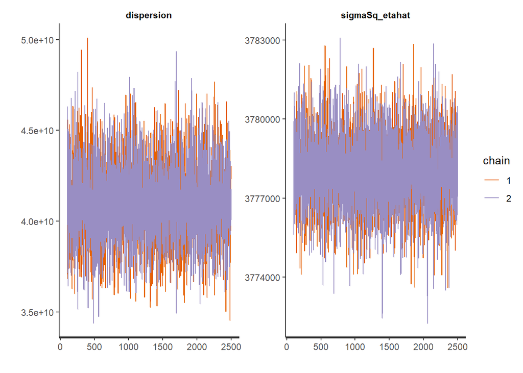

|  | X2 | X3 |
| --- | --- | --- |
| Weights for Selected Base | 0.552505349736369 | 0.447494650263631 |
| Learners: |  |  |

### Variable importance

The “base-learner” importance for a stacked model are simply the weights themselves.

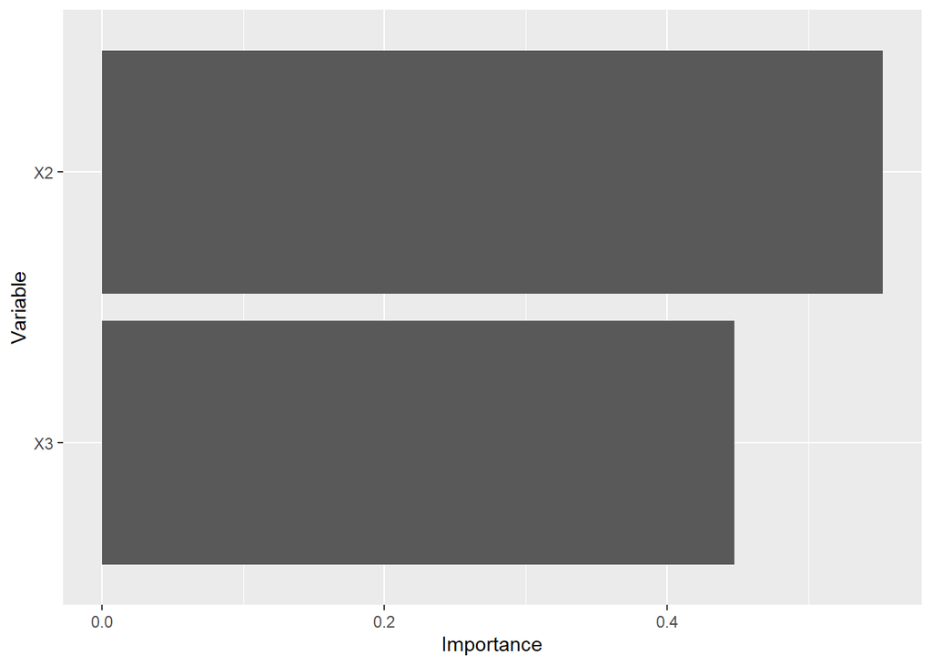

```r
plot(MachineShop::varimp(fit$super_fit,'model',scale = F))
```

For learning about covariates with a stacked model, the permuted model reliance statistic adopted from Fisher et al. 2018 by default in the MachineShop package is used, which can be paired with a custom log-likelihood metric equal to $2(\hat{l} - \hat{l}_{permuted})$; i.e., variable importance can be constructed using something resembling a “psuedo-Wilk statistic”. Note, this is not a real likelihood ratio statistic, just likelihood-ratio inspired.

The permuted model reliance statistic can ALWAYS be performed, even if the base learners have no inherent measures of variable importance (such as with LDA or SVMs and other deterministic-models), or if the model stacks base learners trained on data normalized via feature-reduction techniques such as principal components or k-medoids clustering.

```r
## variable importance of covariates are obtained via a permuted psuedo likelihood-ratio statistic
strt <- Sys.time()
cl <- makeCluster(4)
registerDoParallel(cl)

## make an MLMetric() for use with machine shop based on the link function of the fit object
loss_function <- make_loglikelihood_MLMetric(link_function = fit$super_fit$data$link_function, # link function
                                             tau = fit$super_fit$data$final_fit$tau, # exponential dispersion parameter
                                             double = T) # double the permuted log-likelihood difference for a psuedo-Wilk statistic
clusterExport(cl,c(c(as.vector(lsf.str())),
                   'rec',
                   'loss_function',
                   'fit',
                   'bake',
                   'prep'))
v_obs <- MachineShop::varimp(fit,
                    method = 'permute',
                    metric = loss_function,
                    scale = F,
                    samples = 10)
save(v_obs,file = 'v_boilerplate.RData')
stopCluster(cl)
nd <- Sys.time()
nd - strt
```

```
## Time difference of 20.37615 secs
```

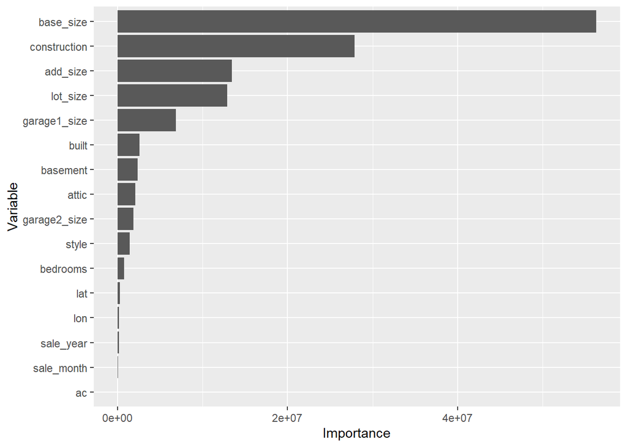

```r
plot(v_obs)
```

# Methods in Detail

## Fitting Conditional Mixed-Effects Models for Unconstrained MLEs

Describe a conditional mixed-effects model for some exponential family model with corresponding link function $g(\cdot)$ as follows, with $p$ fixed effects and $q$ random effects and dispersion parameter $\tau$ for $i=1...N$ observations. $\psi$ may be the cumulant generating function, but is only specified to be some function of the parameter not dependent upon the outcome (to account for non-canonical exponential-family models such as probit regression).

$$\eta_{i} = x_i'\beta + z_i'\gamma = g(\mu_i) \\
E[y_i] = \mu_i = g^{-1}(\eta_i) \\
\gamma \sim N_{q}(0,\sigma^2_{\gamma}\text{I}_q) \\
f_{y_i} \propto exp(\frac{y_i\eta_i- \psi(\eta_i)}{\tau^2})$$

Then the conditional-likelihood is expressed as follows

$$L (\beta,\gamma) = \frac{q}{\sqrt{2\pi\sigma^2}}e^{\frac{-\gamma'\gamma}{2\sigma^2}}\prod^N_i f_{y_i} \\
\log L = \log L(\beta,\gamma)$$

with the following notation.

$$u(\eta_i) = \partial_{\eta_i} \log L \\
w(\eta_i) = -\partial^2_{\eta_i} \log L \\\\
U(\eta) = \begin{pmatrix} u(\eta_1) \\ u(\eta_2) \\ \vdots \\ u(\eta_N)\end{pmatrix} \\
W(\eta) = \begin{pmatrix} w(\eta_1) & 0 & 0 & \cdots \\ 0 & w(\eta_2) & 0 \\ \vdots & 0 & \ddots \\ & & & w(\eta_N) \end{pmatrix} \\
X = (x_1,x_2,...x_N)' \\
Z = (z_1,z_2,...z_N)'$$

The dimension of $u(\eta_i)$ and $w(\eta_i)$ are left unspecified on purpose; for categorical outcomes with $K$ categories, they take on the form of $1 \times (K -1)$ and $(K-1) \times (K-1)$ matrices respectively, which makes generalizing the procedure to categorical outcomes easier to understand.

It’s not hard to realize

$$\frac{\partial \eta_i}{\beta} = x_i' \\
\frac{\partial \eta_i}{\gamma} = z_i'$$

Then, using chain rule where
$$\frac{\partial}{\beta,\gamma} \log L = \frac{\partial \eta}{\beta,\gamma} \frac{\partial \log L}{\eta}$$

one can straightforwardly derive the score as

$$u(\beta,\gamma) = \frac{1}{\tau^2}\begin{pmatrix}
X'u(\eta) \\
Z'u(\eta)-\frac{\tau^2}{\sigma^2_{\gamma}}\gamma
\end{pmatrix}$$

And the information as

$$\mathcal{I}(\beta,\gamma) = \frac{1}{\tau^2}\begin{pmatrix}
X'W(\eta)X & X'W(\eta)Z \\
Z'W(\eta)X & Z'W(\eta)Z + \frac{\tau^2}{\sigma^2}\text{I}_{q \times q}
\end{pmatrix}$$

With this, the Newton-Raphson update for the $Mth$ step is expressed as follows:

$$\begin{pmatrix} \beta \\ \gamma \end{pmatrix} ^{(M)} = \begin{pmatrix} \beta \\ \gamma \end{pmatrix} ^{(M-1)} + \alpha \mathcal{I}(\beta,\gamma)^{(M-1)} u(\beta,\gamma)^{(M-1)}$$

The damp-stepping works as follows. $\alpha = 2^{-ds}$ where $ds$ refers to the number of damp-step attempts previously attempted. For example, at the beginning of each newton-raphson iteration, the first damp-step attempted has a $ds=0$ so a full step is attempted. After each damp-step attempt, the log-likelihood is evaluated at the updated values. If the log-likelihood did not increase, then $ds \ += 1$ and the parameters are not updated, so $\alpha = \frac{1}{2}$ and another damp-step is attempted, this time a half-step. Then if the log-likelihood doesn’t increase, a quarter step is attempted, and so on and so forth. A maximum of 15 damp-step attempts are taken before the algorithm moves on.

When the exponential dispersion parameter is being estimated (i.e. with popular notation $\tau^2 = \sigma^2$ for Gaussian outcomes and $\tau = \phi$ for quasi-Poisson), half-steps are taken following each damp-step of the fixed and random-effect parameters; I call them “maximum-likelihood” estimates, but really, this depends on the outcome being modeled. Below is the code used which illustrates the point.

```r
if(F){
      ## if a survival outcome, half-step the Weibull scale parameter
      if(survival & est_tau){
        Eta <- X %*% cbind(theta_update)[1:length(beta_update),] +
               Z %*% cbind(theta_update)[length(beta_update) + 1:length(u_update),]
        Mu <- mu_of_eta(Eta,tau)
        tau_upd <- 0.5*tau + 0.5*as.numeric(
                                            -crossprod((Y - as.numeric(Eta)),
                                            (d_censored-Mu)/sum(d_censored)))
      }
      ## if a poisson over-dispersed model, half-step the dispersion parameter
      if(link_function == 'log' & est_tau){
        Eta <- X %*% cbind(theta_update)[1:length(beta_update),] +
               Z %*% cbind(theta_update)[length(beta_update) + 1:length(u_update),]
        Mu <- mu_of_eta(Eta)
        tau_upd <- 0.5*tau + 0.5*sqrt(mean((Y - Mu)^2/Mu))*(length(Y)/(length(Y)-length(beta_update)))
      }
      ## if a linear model, half-step the error variance
      if(link_function == 'linear' & est_tau){
        Eta <- X %*% cbind(theta_update)[1:length(beta_update),] +
               Z %*% cbind(theta_update)[length(beta_update) + 1:length(u_update),]
        Mu <- mu_of_eta(Eta)
        tau_upd <- 0.5*tau + 0.5*sqrt(mean((Y - Mu)^2))*(length(Y)/(length(Y)-length(beta_update)))
      }

}
```

Within each damp-step, the log-likelihood is considered AFTER the dispersion parameter is half-step updated.

Variance components for random effects are estimated as the standard deviation (with degrees of freedom $q-1$ for $q$ random effects per variance component) of updated random effects, in-between damp-step iterations.

## Link-Function Weighting

Importantly, nearly all of the theoretical results concerning the behavior of stacking have celebrated its asymptotic minimization of the mean-squared error (MSE) of prediction (Breiman (1996), Le and Clark (2017) ,Charkhi et al 2016, Dormann et al 2018, Van der Laan (2007)), while apparently ignoring the fact that optimizing the MSE is in many cases inappropriate, as it fundamentally ignores any mean-variance relationship. Despite the fundamental principles of generalized linear models (GLM) being so widely accepted in practice, it’s actually quite surprising that so little attention has been devoted to the subject within the context of stacking (perhaps because indeed, the MSE is many times chosen as the optimal criterion for evaluation in competition and benchmarking)

In all fairness, this has been a problem long recognized; many implementations of stacking do not require the MSE to be the loss function specified and for case-by-case circumstances, modifications of stacking have been proposed for special applications, such as for survival right-censored outcomes (Golmakani et al (2020)). However, none of the modifications proposed are as generally applicable as the GLM framework. And surprisingly, none of these adaptions of stacking have considered weighting on a scale other than the raw response.

Authors such as Le Blanc and Tibrishani (1996) mentioned the possibility of such link-function weighting, but did not explore it for themselves. The limited work in the literature that has focused on stacking using GLMs and weighting on the link function scale do not refer to their methodology as `stacking’, and only propose their methodology for contexts in which homogeneous regression models serve as the base learners, from work by Ando et al (2014 and 2017), and Zhang et al (2020); indeed, these authors found that stacking weights on the linear link function scale greatly outperformed stacking without. While these researchers laid down important theoretical groundwork regarding stacking using homogeneous GLM base-learners, they left the development of appropriate tools and inferential procedures to be paired with stacking as a task for future work, and did not explore the behavior of stacking when using heterogeneous base learners.

Below is a clear demonstration of at least one case for which stacking on the link function scale and absolute scale yield completely differing results, with important implications.

### Stacking Paradox

Suppose you had two uncorrelated, unbiased, and equally-performing base learners for predicting the same outcome. Suppose for sake of simplicity this is a binary outcome, and the models are two different logistic regression models for predicting the probability of whatever “success” is defined as $p$.

The unknown but “true” values of parameters will be referred to by $*$, estimates as $^$, and general functions of a parameters un-notationed.

$$Cov(\hat{p}_1,\hat{p}_2) = 0 \\
E[\hat{p}_1] = E[\hat{p}_2] = p^* \\
V[\hat{p}_1] = V[\hat{p}_2] = V$$

Since each learner is unbiased, we need the weights to sum to one, otherwise the stacked learner is biased (or worse, we are using the stacked learner to correct for the bias of poor base learners). We’d like our learners to do a good job of prediction; we certainly don’t want to include any predictors that are negatively correlated with our outcome. Thus, the weights should be non-negative.

A stacked learner can be formulated as
$$\hat{p} = w_1\hat{p}_1 + w_2\hat{p}_2$$

Under constraints

$$w_1 + w_2 = 1 \\
0 \leq w_1 \\
0 \leq w_2$$

With respect to generalized linear models, it can alternatively be formulated on the linear link-function scale $\eta = \log(\frac{p}{1-p})$, for example, with logistic regression.
$$\hat{\eta} = w_1\hat{\eta_1} + w_2\hat{\eta_2} \\
\hat{\eta}_i = \log(\frac{\hat{p}_i}{1-\hat{p}_i})$$

It is intuitive and mathematically true that when the weights are equivalent to 0.5, the variance of the final prediction is minimized. For example, when we stack the two models and the learners are completely uncorrelated, we reduce the variance of our final prediction to one half that of each separately.

$\textit{This is the engine behind why stacking works so well}$.

The point is, whether we choose to model our outcome on the logit scale or raw scale, we optimize our models’ fit by assigning equal weights to two independent and equally performing learners.

Since our link functions are obviously non-linear, stacking on the absolute scale will yield different predictions than stacking on the linear-link function scale (e.g. Jensen’s Inequality). In general, back-transforming weighted predictions from the linear link-function scale yields differing predictions than stacking on the raw scale. For example with the logit-link function,

$$w_1{\hat{p}_1} + w_2{\hat{p}_2} \neq \frac{1}{1+e^{-\big(w_1 \log(\frac{\hat{p}_1}{1-\hat{p}_1}) + w_2\log \big(\frac{\hat{p}_2}{1-\hat{p}_2}) \ \big)}} \\
\text{usually...except sometimes...}$$

There is a simple absurdity to this; we stack the same base learners, we weight them equally, the weights are optimal for both cases, and yet depending whether we weight on the linear link-function scale or on the raw scale, we come away with differing final predictions.

### Simulation of Stacking Paradox

Below, we generate two vectors of random predictions from two uniform distributions, and set the weights to be 0.5.

Based on the exact same weights, and the exact same of ‘base learner’ predictions, we compare the final weighted predictions from each type of stacking model.

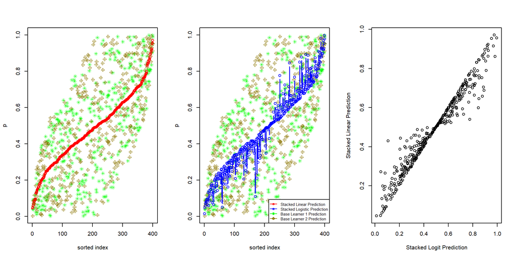

The logistic-regression stacking approach appeared much more sensitive to the extreme predictions of one learner vs. the other, while linear stacking always pulled both predictions towards 0.5.

The connection to the real world becomes concerning when predicting rare outcomes, such as for example, overtime games in the NBA. For rare events, linear stacking (or MSE stacking) will deterministically give results that pull final probabilities towards 0.5.

The obvious point being made is why GLMs are so popular; there should be respect paid to the mean-variance relationship being modeled, and so this package weights on the link-function scale before back-transforming, which is in contrast to most of the literature and software available.

This is the first reason why stacking on the link function scale is so important, but not the only one.

### Another Intuition

In addition to the example above, consider an entirely separate heuristic for weighting on the link function scale as emphasized by Ando et al (2014), Ando et al (2017). Note that when weighting homogenous GLM models (as well as the many other ML models that respect link functions like gradient boosted trees and penalized regression etc.) on the link-function scale, the estimate of each coefficient is literally a weighted average of each model’s estimate; hence, only through stacking on the link function scale is the relationship between covariate and response described by each base learner preserved, with implications for how future inference may be carried out.

$$\hat{\eta}_{stacked} = g(\hat{Y}_{stacked})$$
$$= w_1\hat{\eta}_1 + w_2\hat{\eta}_2 + ... w_k\hat{\eta}_p$$
$$= w_1X\beta_1 + w_2X\beta_2 + ...w_pX\beta_p$$
$$= X(\sum^p_{j=1}w_j\beta_j)$$
$$= X\beta^*$$

The weighting system, and stacking on the link-function scale, essentially allows one to shove a lot of parameters into one otherwise-ordinary GLM model while simultaneously $\textit{reducing}$ variability in predictive performance, which counters our usual intuition reflecting the bias-variance tradeoff. This may be an awful strategy for some research scenarios, but for the data we have and purposes of prediction, this is actually a $\textit{good}$ thing.

## Optimizing under constraint

### Rsolnp

There isn’t really anything more complicated to explain for maximizing the likelihood using Rsolnp; as long as the likelihood function is explicitly described, the computer does the rest.

Below is the heart of the code that executes the procedure for illustration.

```r
if(F){
solnp(beta_update,
                          function(weights) -compute_loglik(Y,
                                                            X,
                                                            Z,
                                                            ifelse2(softmax,
                                                                    lapply(weights,function(weight)diag(weight,ncol(cbind(Y)))),
                                                                    weights),
                                                            u_update,
                                                            tau,
                                                            cumgenfunc,
                                                            C,
                                                            sigmas,
                                                            sigma_list,
                                                            probit,
                                                            softmax_function = softmax),
                          eqfun = function(x) sum(x), eqB = sum_constraint,
                          LB = LB,
                          control = list(trace = FALSE))$pars
}
```

### quadprog

Quadratic programming is a more specialized procedure and requires some explanation.

In addition to being able fit more complicated models (such as for example, quasi-likelihood which requires specification only of the first two moments) I found in my own experience that this approach tends to be faster than solnp and less sensitive to initial values. It does require some math however. The following derivations are actually adapted from the homework exercises provided by Dr. Breheny as the first problem of homework 6 in his likelihood theory course of 2020 https://myweb.uiowa.edu/pbreheny/7110/f20/assignments/6.pdf.

From the theory behind GLMs, the third-order TSE of a regular exponential-family model exists and can be expressed as follows

$$\log L(\beta) = \log L(\beta^*) + u(\beta^*)'(\beta - \beta^*) -\frac{1}{2}(\beta - \beta^*)'\mathcal{I}(\beta^*)(\beta - \beta^*) + \mathcal{O}_p(||\beta - \beta^* ||)$$

This can be re-expressed as.

$$\log L(\beta^*) - \log L(\beta) = -[u(\beta^*) + \mathcal{I}(\beta^*)\beta^*]'\beta +
\frac{1}{2}\beta'\mathcal{I}(\beta^*)\beta + C(\beta^*) + \mathcal{O}_p(||\beta - \beta^* ||)$$

Where
$$\beta = \text{parameter(s) of interest (i.e. the weights of a stacked model)} \\
\beta^* = \text{A value of the parameter(s) about which a TSE is taken} \\
\log L(\beta) = \sum^N_{i=1}\log p(y_i|\beta) = \text{Log-likelihood for } i = 1...N \text{ Observations} \\
u(\beta) = \sum^N_{i=1}u_i(\beta) = \text{Score: the gradient of the log-likelihood } \\
\mathcal{I}(\beta) =\sum^N_{i=1}\mathcal{I}_i(\beta)=\text{Information: the negative Hessian of the log-likelihood} \\
C = \text{Function of }\beta^*\text{ that does not depend on } \beta$$

To find the values of $\beta$ that maximize $l(\beta)$, one can minimize $l(\beta^*)-l(\beta)$ which is a quadratic-programming problem of the form (as expressed by the quadprog package in R)

$$\text{QP} = \text{argmin}_{\text{x}} \{-\text{d}'\text{x} + \frac{1}{2}\text{x}'\text{D}\text{x} \}$$

$$= \text{argmin}_{\beta} \{ -[u(\beta^*) + \mathcal{I}(\beta^*)\beta^*]'\beta +
\frac{1}{2}\beta'\mathcal{I}(\beta^*)\beta\}$$

$$= \text{argmin}_{\beta}\{\log L(\beta^*) - \log L(\beta)\}$$
$$= \text{argmax}_{\beta}L(\beta)$$

Under arbitrary inequality constraints

$$\text{A}'\beta \ \succeq \text{b}$$

For $p$ base learners, weighted under sum-to-one and non-negativity constraints, the inequality constraints on the vector of scalar weights $\beta$ can be expressed by

$$\begin{pmatrix}\text{1}_{p \times 1}, \text{I}_{p \times p}\end{pmatrix}'\beta \succeq (1,0,0,....0)_{1 \times (p+1)}$$

Note, $\beta^*$ is not specified to be any one value in particular, suggesting the possibility of an iterative scheme. With initial values as the unconstrained MLEs, for each iteration of the optimization problem, the information, score, and QP program are updated and evaluated at the new constrained mles. Eventually, the algorithm should converge at some $\beta^* \approx \beta$, thus, the third-order bounded term should converge to 0.

Simple code for fitting GLM models in this way using quadprog (for a single iteration) drives home the point.

```r
if(F){
  solve.QP(
    Dmat = info, # information
    dvec = score + info %*% cbind(beta), # score plus information times coefficients
    Amat = cbind(1, # coefficients are constrained to sum to 1
                 diag(length(beta))), # coefficients are constrained to be greater than 0
    bvec = c(1, # coefficients are constrained to sum to 1
             rep(0,length(beta))), # coefficients are constrained to be greater than 0
    meq = 1 # the first element of the bvec above refers to an equality constraint, the rest are lower bounds
  )
}
```

The first downside of the QP approach is that the quadprog package requires positive-definiteness of the information matrix; this is usually not a problem with parsimonious stacked models, but may be when many base learners are being considered at once (such as when shoving a bunch of base learners into my make_glmerStackedModel() with stepAIC_stacked()). The nearPD() function of the Matrix package is used to force the information to be positive definite, which usually changes it very little. However, this is a risk the user should understand before using the package, as the nearPD() matrix is not at all guaranteed to be similar to the information, and it is possible for the algorithm to converge at very different values other than the true constrained MLEs. In order to (sometimes) mitigate this, I included an l2-norm penalty in the glmer_constrained() argument which if used effectively, can help the information become positive definite, as is a celebrated property of ridge regression. It defaults to a small value for stacking.

Second, not really a downside, it must be noted that the algorithm has to be adapted for categorical outcomes, since quadprog assumes the outcome of interest, the parameters of interest, and the gradient of the function are all represented as vectors (which are instead represented by matrices for 3+ categorical outcomes). Hence, a projection is needed, the operation for which is described below

Since the quadratic programming formulation for categorical regression outputs to a $(K-1) \times (K-1)$ matrix, we pre and post-multiply by $\frac{1}{K-1}1'_{K-1}$ which projects onto (as desired) a scalar value.

$$dim\{ -[u(\beta^*) + \mathcal{I}(\beta^*)\beta^*]'\beta +
\frac{1}{2}\beta'\mathcal{I}(\beta^*)\beta\} \\ = (K-1)\times(K-1)$$

$$dim \{ -\frac{1}{K-1}1'_{K-1}\big(
[u(\beta^*) + \mathcal{I}(\beta^*)\beta^*]'\beta+
\frac{1}{2}\beta'\mathcal{I}(\beta^*)\beta \big)\frac{1}{K-1}1_{K-1}\} \\
= \{1 \times (K-1)\} \times \{(K-1)\times(K-1)\} \times \{(K-1) \times 1\} \\
= 1 \times 1$$

This conveniently decomposes into one rowMeans() operation in R; since $\frac{1}{K-1}1'\beta$ $\textit{is}$ in fact, the argument $\beta$ that minimizes the QP problem, it doesn’t appear in the explicit formulation. And since this operation does not affect the information (which is still $p \times p$), only the the term $d = u(\beta^*) + \mathcal{I}(\beta^*)\beta^*$ needs to be explicitly adjusted.

The full code for fitting quadratic programming problems in my package, used for categorical as well as all other outcomes, is presented below which may help illustrate the point. The reason you see ‘beta update’ is that this is wrapped in a iterative procedure; the information and score is evaluated at the constrained wieghts for purposes of finding the next-iteration’s constrained weights.

Random effects are fixed to be their values returned when estimating the unconstrained MLE weights.

```r
if(F){
  solve.QP(
        as(nearPD(info_update[1:length(beta_update),1:length(beta_update)])[[1]],'matrix')/sc,
        dvec =
          cbind(

            ## for multinom where k = 3,
            ## rowMeans() projects a (k-1)-dimensional space onto 1-dimensional space
            ## = the matrix operation (1/2,1/2....)'  %*% [-db + .5b'Db] %*% (1/2,1/2.....)
            rowMeans(cbind(
              cbind(score_update)[1:length(beta_update),] + #
                info_update[1:length(beta_update),1:length(beta_update)] %*%
                cbind(theta_update)[1:length(beta_update),]))
          ) / sc,
        Amat = cbind(1,diag(length(beta_update))),
        bvec = c(sum_constraint,ifelse2(length(lower_bound_constraint) == length(beta_update),
                                        lower_bound_constraint,
                                        rep(lower_bound_constraint,length(beta_update)))),
        meq = 1
      )$solution
}
```

## Turning Stacking into a Likelihood

As presented in the introduction, we have a pretty slick prior. The downside is, now we need an even $\textit{better}$ model.

Consider this; our decision of whether to bet or not is based directly on our prior being off, as in, we only place a bet if OUR model convinces us Vegas’s best-guess of the true mean (actually, the best-guess of what they think other people think is the true mean) is off.

It’s very easy to make a parsimonious and high-performing model with the massive amounts of clean, high-quality data provided by the NBA, and posterior-predictive distributions can often be derived in simple closed-form with this approach. But unless you construct more powerful models, you’ll find (maybe, like I did) that simple parsimonious models aren’t strong enough to overpower the prior; correctly, my posterior-predictive distributions told me no bet was worth it. It may not be obvious, but if we’re going to profit, we need to gain an edge on all the other folks and NBA-crazed fans and Vegas quants out there, except we all basically have access to the same data, so it’s an arms race.

When prediction is priority, it’s natural to turn to the world of Machine Learning; re-capturing the interaction effects described by a single gradient-boosted tree alone would require a massive effort to implement in an otherwise-ordinary frequentist or Bayesian model (although it isn’t impossible, you have to manually specify each level of interaction yourself). Even though it may not be obvious in general how we can get from a machine learning model to a likelihood, for situations like these (in which we have a giant clean data set where most if not all of the covariates have meaningful-albeit-complicated associations with the outcome of interest and we don’t care about false discoveries anyways) machine learning simply dominates at tasks of prediction, and can fit models with complexity far beyond what would be feasible otherwise.

### Stacking 101

A deep and excellent review of stacking, as well as other model-averaging methods and its usage for ecological research, are given by Dormann et al (2018).

Stacking is a procedure most-often credited to Wolpert (1992) who argued for “stacked generalization” in the context of neural networks, and Breiman (1996) who extended it to the regression setting. Although often explained in much more rigorous terms, it amounts to little more than running one model on the cross-validated predictions of other models. Although there are infinite variations one can do, the core procedure is as follows.

1. Run cross-validation on individual models (hereby referred to as base learners).
2. Save out-of-fold predictions to a new data set (as if it were a new design matrix).
3. Treat the out-of-fold predictions of base learners as covariates, and run another model on them (hereby referred to as the meta learner); the coefficients of this model become the weights of the stacked model, and are often constrained to be non-negative and sum-to-one.
4. Afterwards, re-fit all base learners to the full data set; future predictions are thus the weighted average of base learner predictions when fit to the full data set.

The behavior of stacking can largely be described with some of the most basic rules of probability theory. Consider two base learner predictions $\eta_1$ and $\eta_2$ predicting some outcome of interest with weights $w_1$ and $w_2$ respectively.

$$Var(w_1\eta_1 + w_2\eta_2) = w_1^2Var(\eta_1) + w_2^2Var(\eta_2) + 2w_1w_2Cov(\eta_1,\eta_2).$$

Note the following

$$1) \ If \ 0 \leq w_j \leq 1 \ \forall j \\
Then \ w_1^2Var(\eta_1) + w_2^2Var(\eta_2) \leq Var(\eta_1) + Var(\eta_2) \\
2) \ If \ Cov(\eta_1,\eta_2) \uparrow \\
Then \ \ Var(w_1\eta_1 + w_2\eta_2) \uparrow$$

Stacking’s success comes down to this trade-off between the variance reduction in the final estimate induced by the weights, and the variance increase due to the covariance between base learners, plus the variance of base learners themselves; hence, it is desirable to stack a diverse combination of high-performing base learners.

### Choosing base learners

One of the glaringly obvious questions when stacking in practice is “what base learners should I use?”. Obviously, we can’t evaluate every possible combination of base learners we may be potentially considering with nested cross-validation; that could take years to fit. AIC is traditionally considered a metric for out-of-sample performance per Dr. Smith’s course notes, and some research has shown that asymptotically speaking, best subset selection using AIC and leave-one-out cross-validation will select the same model out of a set of potential candidates (Stone (1977), Fang (2011)) for linear regression, so it’s an attractive alternative.

Briefly, one of the main issues with backwards variable selection via AIC, as discussed in Dr. Cavanaugh’s model selection seminar, is that it’s motivated by the thought experiment of going from an over-saturated to saturated model. Of course, this rarely holds in scientific research, but arguably for stacking, this is exactly the case; we are considering inclusion for a bunch of big-black-box machine learning models, all of which (frankly speaking) are probably going to over-fit in some way. We absolutely $\textit{are}$ comparing over-saturated models, justifying this double entendre of “model selection”.

However, and I’m not at all sure, but I do not believe the AIC is a true AIC because of the sum-to-one and inequality constraint, as well as the fact that base learners are themselves functions of parameters of unknown dimension. Nonetheless, it’s useful; pragmatically speaking, AIC maximizes the out-of-fold likelihood with a relatively small penalty $p$ on the number of base learners.

Hence, I implemented backwards base-learner selection via AIC (AICc for linear outcomes) for purposes of choosing the best combination of base learners. Don’t think about it too hard; once we obtain the out-of-fold predictions and save it to a new design matrix, the base learner predictions might as well be height weight and sex, and we just run backwards selection without having to run any more rounds of cross-validation.

### Quantifying Uncertainty

Of course, stacking alone doesn’t help us at all in our original goal; to bet on NBA over/unders, we need a likelihood, not a big-black-box machine learning model. This goes deep to the idea that for many real-world scenarios (outside of special exceptions like recommendation systems where incorrect predictions don’t really matter, or self-driving cars where there can’t be incorrect predictions) predictions are pretty much useless without some quantification of uncertainty about that prediction.

An insurance company frankly does not care how long a patient lives. What matters is that their expected profit for insuring a patient is positive.

When providing predictions on how mask mandates affect COVID mortality, how ‘close’ the predictions get to the actual mortality data doesn’t matter much; what matters is the uncertainty associated with those predictions, i.e., how confident can a researcher (or politician, more importantly/unfortunately) be that a mask mandate will help?

I have never impressed anybody at my research assistantship (actually, nobody ever) with a small MSE, MAE, FDR or $R^2$, only my ability to confidently report results with as few numbers and acronyms as possible.

When betting on NBA games, getting close to the final score is fun, but all that really matters is that the posterior distribution being derived is honest, else misinformed bets might be made.

In the machine-learning world, cross-validation is the go-to tool for “quantifying” uncertainty. But for stacking, cross-validating is especially awful for many reasons, below being three of the most important:

1. A stacked model already requires cross-validation; running cross-validation on a stacked model requires at least two rounds of nested cross-validation, which is ridiculously computationally intensive.
2. Furthermore, with nested cross validation, the base learners might yield very different models than when trained on the entire data set; for example, with two rounds of 10-fold cross validation, base learners are only being trained on 81% of the data set, something especially problematic for models that themselves rely on sub-sampling techniques such as gradient boosted trees, random forests, and neural nets fit via stochastic gradient descent.
3. Additionally, if a backwards base-learner selection procedure is used (as is implemented in AbsolutelyStacked), the stacked models being evaluated on cross-validated training data may weight a completely differing combination of base learners than the final stacked model trained on the entire data set.

Simply, cross-validation $\textit{does not}$ evaluate the stacked model you end up with. To REALLY quantify uncertainty, we need something we can apply to the final-fitted stacked model.

### Posterior-Predictive Distributions from Stacking

So far we’ve hit the frequentist GLM models for finding optimal weights, we used the information theoretic approach for selecting an optimal combo of base learners, and we used machine learning to add some predictive power. It’s time to go Bayesian.

#### The Basic Idea

The idea I proposed was to treat stacking as an otherwise unremarkable task of maximizing the likelihood of a GLM model under the constraint the coefficients (i.e. the weights) are non-negative and sum-to-one. If GLMs are used as meta-learners, it should be possible to construct a likelihood. And as we have a prior, with some hard work there should be a way to derive a posterior-predictive distribution for a future observation of interest.

#### The Problem

In a regular Bayesian model, the posterior-predictive distribution for a new, unobserved response variable $Y^{New}$ given the past observed data $Y^{Old}$, which follows some distribution parameterized by $E[Y_i] = \mu_i = g^{-1}(x_i'\theta)$ for some link function $g$ of an exponential family ($EF$) model, can be expressed as follows and is straightforwardly solved with an ordinary application of Bayes rule.

$$P(Y^{New}|Y^{Old})$$

$$= \int P(Y^{New} |Y^{Old},\beta)[P(\beta|Y^{Old})]d\beta$$

$$= \int P(Y^{New} |Y^{Old},\beta)[\frac{P(Y^{Old}|\beta)P(\beta)}{P(Y^{Old})}]d\beta$$

$$= \int P(Y^{New} |\beta)[\frac{P(Y^{Old}|\beta)P(\beta)}{\int P(Y^{Old}|\beta)P(\beta)d\beta}]d\beta$$

However, in a stacked model, a researcher often does not have tractable access to $\beta$. For example, consider stacking multiple neural networks or random forests; there may be hundreds if not thousands (and sometimes millions) of parameters being estimated; setting appropriate prior distributions on all of them, and integrating each of them out is technically possible, but obviously not preferred.

One alternative is to instead, attempt to reconstruct the final stacked model’s linear link-function predictor $\eta = g(\mu)$ as a function of $X$, the raw covariates, and $\beta$, through some function $f(X,\beta)$. An analogy using OLS would be estimating the linear predictor $\eta = X\beta$ instead of $\beta$; obviously, any inferences one draws upon $\eta$ would imply some inference upon $\beta$. A basic example of this process is used in regression when identifiability is an issue; when the variance-covariance matrix isn’t positive-definite, a linear-combination of coefficients is estimated instead of each coefficient individually. Same idea here, but the function could be anything.

The key issue is, for an ordinary GLM base learner, the relationship between response and covariates are assumed to be known and conditioned upon; however, in a stacked model, there is uncertainty associated with the relationship between response and covariate, as the stacked model for all practical purposes is a weighted average of many black box models, base learners which may (and virtually always will) propose completely differing forms of relationships between covariates and response. $f(X,\beta)$ is unknown. Without a parameter $\beta$ and a covariate-response relationship specified, it is certainly not clear how (or if) constructing a valid posterior distribution is possible. However, the subjective Bayesian perspective reminds us that uncertainty can be quantified.

#### A Solution

For building intuition on how one may quantify this uncertainty, it’s helpful to consider the ordinary least squares case without stacking first, in which $\sigma^2$ is a known quantity.

$$Y_{i=1...N} = x_i'\beta + \epsilon_i, \ \epsilon_{i=1...N} \sim N(0,\sigma^2\text{I}_N)$$

Let $\hat{\eta} = X\hat{\beta}$ be the maximum likelihood estimate of the expected value of $E[Y] = \eta = X\beta$. Then, it follows trivially that

$$P(\hat{\eta}|Y,X)\sim degenerate: \hat{\eta} = X(X'X)^{-}X'Y$$

Conditional upon the response variable (i.e. treating $Y$ as fixed) there is NO uncertainty associated with the value of $\hat{\eta}$ for OLS $\textit{as long as the relationship between covariates X and response Y is known}$. In other words, the probability density function for the MLE $\hat{\eta}$ of a normal distribution, conditional upon the observed data and the mean taking on the commonly specified form $X\beta$, is deterministically the least-squares solution above. However, if the mean-response relationship isn’t $E[y_i] = x_i'\beta$, for example if the $jth$ covariate wasn’t actually related to the outcome of interest, then $\hat{\eta}$ would take on a different form, where $X^{-j}$ is the design matrix of covariates with the $jth$ column excluded,

$$P(\hat{\eta}|Y,X^{(-j)})\sim degenerate: \hat{\eta} = X^{(-j)} ({X^{(-j)}}' X^{(-j)})^{-} {X^{(-j)}}'Y$$

Hence, the above formulation implicitly conditions upon a known response-covariate relationship, relating uncertainty about future observations to an assumed data-generating process; below is a formulation that does not condition upon this relationship.

$$P(\hat{\eta}|Y,X) = \int P(\hat{\eta}|Y,X,\eta=f(X,\beta))P(1_{\eta = f(X,\beta})d1_{\eta = f(X,\beta))}$$

This generalizes the notion that the relationship between $Y$ and $X$ can be described by an unspecified function of $\beta$ and $X$ other than $\eta = X\beta$.

In general, outside of the cases in which the covariate-response relationship is presumed, this is solely an abstract quantity. The marginal distribution of $P(\hat{\eta}|X,Y)$ without an explict covariate-response relationship involves integration over a set of functions. To compute the “integral” (if it’s even an integral at all) would require the researcher to explicitly quantify their degree of belief in each of the possibly infinite valid covariate-response relationships.

Instead, rather than try to deal with this integral directly, consider the joint distribution of $P(\eta, 1_{\eta = f_k(X,\beta)} |Y, X)$ for $K = 1....\infty$ possible covariate-response relationships, and suppose it can reasonably quantified via a normal distribution.

$$P(\hat{\eta},1_{\eta=f(X,\beta)}|Y,X,\eta) \sim N(\eta,\sigma^2_{\hat{\eta}})$$

Hence, to recover our beliefs about $\eta$ for purposes of deriving a posterior-predictive distribution, we only need to know $\hat{\eta}$, the prediction of our stacked model, and a posterior distribution for $\sigma^2_{\hat{\eta}}$ which captures the uncertainty of an unknown function of the data-generating parameters of interest, and how close it can be approximated by the stacked model’s prediction on the link-function scale.

Finding the conditions under which this holds is a work in progress, I would love to talk about it more (reach out if you are interested or have a better idea) but it goes beyond this final project. The oversimplified idea is, we have about infinite possible valid models we are willing to consider when stacking, so evaluating that abstract integral can be interpreted as an infinite sum. We won’t accept non-finite predictions from base learners, and we can be reasonably confident that whatever link-transformed predictions are returned by the stacked model, they will on the whole, be centered about the “true” value, perhaps symmetrically so on the link-function scale. Hence, the discrepancy between $\hat{\eta}$ and $\eta$ conditional upon any given covariate response relationship is a fixed, bounded term, that a priori as far as we know, is finite and more likely to be close to the true value than far from it. Infinite sum of bounded terms centered about some true value => normal…..???? I don’t know if it will work, but I’m still betting on it.

## Deriving a Posterior Predictive Distribution

Now, with this in mind, return to the issue of deriving a posterior-predictive distribution for an unobserved outcome of interest treating a stacked model as a likelihood.

The explicit notation of $1_{\eta = f(X,\beta)}$ will be dropped for algebraic convenience, but nonetheless, remains as a random, unknown quantity. For emphasis again, this uncertainty is why $P(\hat{\eta}|\eta,\sigma_{\hat{\eta}},Y)$ follows a distribution instead of being degenerate, as it otherwise would be for ordinary GLMs.

### Notation

$$Y^{New}: \text{Outcome of interest we are trying to predict i.e. total sum-of-points} \\
Y^{Old}: \text{Past outcomes in our training data} \\
\eta^{New}, \eta^{Old}: \text{True, linear link-function transformed-parameters for new and training data respectively} \\
\hat{\eta}^{New}, \hat{\eta}^{Old}: \text{Stacked-model's final prediction on the linear link-function scale} \\
\sigma^2_{\hat{\eta}}: \text{Variance parameter capturing the discrepancy between the stacked model's prediction and the true linear link-function transformed-parameter}$$

### Step 1

Find the distribution for a new response variable $Y$ conditional upon the stacked model’s link-function prediction for the new outcome $\hat{\eta}^{New}$ and the stacked model’s fitted link-function predictions on past data, $\hat{\eta}^{Old}$.

$$P(Y^{New}|\hat{\eta}^{New},\hat{\eta}^{Old},Y^{Old}) = \int P(Y^{New} | \eta^{New},\hat{\eta}^{New},\hat{\eta}^{Old},Y^{Old})P(\eta^{New}|\hat{\eta}^{New},\hat{\eta}^{Old},Y^{Old})d\eta^{New}$$

By Bayes rule, and under the assumptions $P(Y^{New} | \eta^{New}, \hat{\eta}^{New},\hat{\eta}^{Old},Y^{Old}) = P(Y^{New} | \eta^{New})$ (new values of outcome variable are independent of past outcomes, conditional upon the parameter $\eta$, which reflects the oft-taken-for-granted independence of observations) and $P(\eta^{New} | \hat{\eta}^{Old},Y^{Old}) = P(\eta^{New})$ (past observations are not informative to our prior beliefs on future observations, for example, our prior distribution is based only on Vegas’s prediction today).

$$\propto \int P(Y^{New} | \eta^{New})
P(\hat{\eta}^{New}|\eta^{New},\hat{\eta}^{Old},Y^{Old})P(\eta^{New})d\eta^{New}$$

Assume $P(\hat{\eta}^{New}|\sigma_{\hat{\eta}},\eta^{New},\hat{\eta}^{Old},Y^{Old}) \equiv P(\hat{\eta}^{New}|\sigma_{\hat{\eta}},\eta^{New})$ (this again, just reflects independence of observations).

$$\propto \int P(Y^{New} | \eta^{New})
[\int P(\hat{\eta}^{New}|\sigma_{\hat{\eta}},\eta^{New})P(\sigma_{\hat{\eta}} | \hat{\eta}^{Old},Y^{Old}) d\sigma_{\hat{\eta}}]P(\eta^{New})d\eta^{New}$$

$$\propto \int P(Y^{New} | \eta^{New})
[\int \{ \int P(\hat{\eta}^{New}|\sigma_{\hat{\eta}},\eta^{New},Y^{New})P(Y^{New}|\eta^{New})dY^{New}\}P(\sigma_{\hat{\eta}} | \hat{\eta}^{Old},Y^{Old}) d\sigma_{\hat{\eta}}]P(\eta^{New})d\eta^{New}$$

Tractable terms so far include, for some arbitrary exponential family GLM (EF)
$$P(Y^{New}|\eta^{New}) \sim EF(g^{-1}(\eta^{New}))$$

as well as

$$P(\eta^{New}) \sim Custom \ Prior$$

and

$$P(\hat{\eta}^{New}|\sigma_{\hat{\eta}},\eta^{New},Y^{New}) \sim N(\eta^{New},\sigma_{\hat{\eta}})$$

The only unspecified distribution thus far is $P(\sigma_{\hat{\eta}}| Y^{Old},\hat{\eta}^{Old})$ and it can be derived as follows.

### Step 2

$$P(\sigma_{\hat{\eta}}|Y^{Old},\hat{\eta}^{Old})$$

$$= \frac{P(Y^{Old},\hat{\eta}^{Old}|\sigma_{\hat{\eta}})P(\sigma_{\hat{\eta}})}{
P(Y^{Old},\hat{\eta}^{Old})
}$$

$$\propto P(\hat{\eta}^{Old}|\sigma_{\hat{\eta}},Y^{Old})P(Y^{Old}|\sigma_{\hat{\eta}})P(\sigma_{\hat{\eta}})$$

The below step assumes $P(Y|\eta,\sigma^2_\eta) = P(Y|\eta)$ (as in, $\sigma^2_{\hat{\eta}}$ is uninformative to $Y$ conditional upon $\eta$).

$$\propto \int P(\hat{\eta}^{Old}|\sigma_{\hat{\eta}},Y^{Old},\eta^{Old})P(Y^{Old}|\eta^{Old})P(\eta^{Old})d\eta^{Old}]P(\sigma_{\hat{\eta}})$$

Note then, all terms are tractable.

$$P(\hat{\eta}^{Old}|\sigma_{\hat{\eta}},\eta^{Old},Y^{Old}) \sim N(\eta^{Old},\sigma_{\hat{\eta}})$$

$$P(Y^{Old}|\eta^{Old}) \sim EF(g^{-1}(\eta^{Old}))$$

$$P(\sigma_{\hat{\eta}}) \sim Custom \ Prior$$

$$P(\eta^{Old}) \sim Custom \ Prior$$

A researcher must decide how to assign prior distributions to $\eta$, which (demanding-ly) requires one per each observation in the past data set (and K-1 per each observation for categorical outcomes). How best to assign a prior will always depends on the context of the research being conducted. In the quantify_stacked_uncertainty() function I’ve provided, relatively uninformative normal distributions are set upon each $\eta$ centered about link-transformed averages of the outcome of interest. The posterior distributions for all $\eta$ are assumed not informative to future observations, and so are marginalized over to obtain distributions of dispersion and variance parameters.

The key is to recognize, again, that the uncertainty associated with $P(\hat{\eta}^{Old}|\sigma_{\hat{\eta}},Y^{Old},\eta^{Old})$ is due to the uncertainty with respect to the response-covariate relationship in a stacked model (how well can the stacked-model’s predictions approximate an unknown data-generating process); for any ordinary generalized linear regression model, this term would be 1, as $\hat{\eta}$, the MLE, is deterministically specified once a covariate-response relationship is specified AND the data is observed. In fact, if one were to consider the entire formulation above but conditional upon a known covariate-response relationship, you would find that the formulas collapse into the familiar and ordinary form of the Bayesian posterior-predictive distribution, independent of parameter $\sigma^2_{\hat{\eta}}$.

### Step 3

Once the posterior density of $\sigma^2_{\hat{\eta}}$ is obtained, plug back in to the expression in Step 1: all terms are now tractable, and a posterior-predictive distribution for $Y^{New}$ can be straightforwardly derived.

When estimating the posterior density of a dispersion parameter, for example with the normal distribution’s variance parameter $\sigma$ i.e. $Y \sim N(\eta,\sigma^2)$, the procedure can be modified.

From step 2,

$$P(\sigma_{\hat{\eta}},\sigma|Y^{Old},\hat{\eta}^{Old}) \propto \int P(\hat{\eta}^{Old}|\sigma_{\hat{\eta}},Y^{Old},\eta^{Old},\sigma)P(Y^{Old}|\eta^{Old},\sigma)P(\eta^{Old})d\eta^{Old}]P(\sigma_{\hat{\eta}})P(\sigma)$$

From step 1,

$$P(Y^{New}|\hat{\eta}^{New},\hat{\eta}^{Old},Y^{Old}) \propto \\
\int \int P(Y^{New} | \eta^{New},\sigma)
[\int \{ \int P(\hat{\eta}^{New}|\sigma_{\hat{\eta}},\eta^{New},Y^{New},\sigma)P(Y^{New}|\eta^{New},\sigma)dY^{New}\}P(\sigma_{\hat{\eta}} | \hat{\eta}^{Old},Y^{Old},\sigma) d\sigma_{\hat{\eta}}]P(\sigma |\hat{\eta}^{Old},Y^{Old})P(\eta^{New})d\eta^{New}d\sigma$$

# Full-Pipeline for Betting on NBA

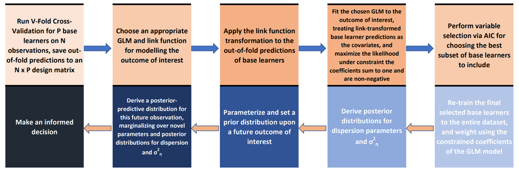

FlowChart for the general procedure being proposed.

## The Data

Briefly, it’s worth mentioning what I’m even modelling. The nbastatR package is wonderful; I’ve provided a wrapper, which automatically pulls and transforms data from several news outlets online into a usable format.

I pulled a bunch of data from 2010-the present day which gave me just over 15200 observations, each observation being a unique game (with several potential outcomes), and over 386 unique covariates. This is team-level data, the effect of individual players are not considered.

I only included an extremely small version of the file for data-uploading purposes, but all of the code and data you need for reproducing your own data set is included. As of December 9th 2021, there are 15234 observations and 386 unique covariates.

```r
load('recipes_playoffs_small.RData')
#dim(df)
pander(head(df[1:4,1:4]))
```

Table continues below

|  | fgmTeamPerMinute.x | fgaTeamPerMinute.x |
| --- | --- | --- |
| **1:DEN_2010atPOR_2010** | 0.1375 | 0.3208 |
| **12:GSW_2010atPHX_2010** | 0.1708 | 0.3333 |
| **15:CHA_2010atCLE_2010** | 0.1208 | 0.3278 |
| **17:POR_2010atHOU_2010** | 0.125 | 0.3375 |

|  | fg3mTeamPerMinute.x | fg3aTeamPerMinute.x |
| --- | --- | --- |
| **1:DEN_2010atPOR_2010** | 0.04167 | 0.0875 |
| **12:GSW_2010atPHX_2010** | 0.02917 | 0.0625 |
| **15:CHA_2010atCLE_2010** | 0.03333 | 0.08472 |
| **17:POR_2010atHOU_2010** | 0.02083 | 0.075 |

Covariates are grouped in two ways; first, by home team (denoted with a “.x”) and away team (denoted with a “.y”). Second, by it’s value for the last game (denoted by ‘LastGame’) and a weighted average of the second-to-last game and before. Many covariates are normalized as stat-per-minute instead of raw, because the raw stat wouldn’t take into account the additional minutes associated with overtime.

```
## 'data.frame':    10 obs. of  25 variables:
##  $ drtgE.y                             : num  105.3 108.2 104.1 87.2 120.5 ...
##  $ fgmTeamPerMinute.x                  : num  0.138 0.171 0.121 0.125 0.136 ...
##  $ ftmTeamPerMinuteLastGame.y          : num  0.0958 0.0625 0.1 0.1375 0.1083 ...
##  $ passesPerMinuteLastGame.y           : num  0 0 0 0 0 0 0 0 0 0
##  $ pctASTLastGame.y                    : num  0.512 0.568 0.514 0.571 0.485 0.5 0.514 0.647 0.475 0.563
##  $ pctFG2MasUnassisted.y               : num  0.553 0.475 0.565 0.435 0.588 ...
##  $ pctFGRimDefended.y                  : num  0 0 0 0 0 0 0 0 0 0
##  $ pctOREBOpponent.x                   : num  0.236 0.289 0.22 0.4 0.308 ...
##  $ pctOREBOpponentLastGame.x           : num  0.236 0.289 0.34 0.375 0.389 0.196 0.233 0.353 0.109 0.294
##  $ pctPTSasFB.y                        : num  0.123 0.178 0.136 0.083 0.177 ...
##  $ pctPTSasFBLastGame.y                : num  0.123 0.178 0.147 0.032 0.124 0.115 0.144 0.115 0.099 0.252
##  $ pctPTSasOffTOVLastGame.x            : num  0.219 0.119 0.183 0.185 0.085 0.252 0.291 0.118 0.126 0.266
##  $ pctTOVOpponentLastGame.y            : num  0.16 0.18 0.151 0.094 0.125 0.127 0.149 0.17 0.165 0.115
##  $ pctTS.x                             : num  0.554 0.593 0.482 0.464 0.553 ...
##  $ pfdPerMinute.x                      : num  0.1083 0.1 0.1208 0.1125 0.0944 ...
##  $ pfdPerMinuteLastGame.x              : num  0.1083 0.1 0.0625 0.0917 0.1125 ...
##  $ pfdPerMinuteLastGame.y              : num  0.0833 0.0917 0.0966 0.125 0.1 ...
##  $ plusminusTeamLastGame.y             : num  9 -1 2 -3 5 -17 -19 -10 4 -10
##  $ ptsOffTOVOpponentPerMinuteLastGame.y: num  0.0333 0.0833 0.0483 0.05 0.0458 ...
##  $ ptsSecondChanceOpponentPerMinute.x  : num  0.0458 0.0417 0.0458 0.0583 0.0389 ...
##  $ ptsSecondChancePerMinuteLastGame.x  : num  0.0583 0.05 0.0333 0.0583 0.0417 ...
##  $ ptsTeamPerMinute.x                  : num  0.4 0.454 0.376 0.362 0.388 ...
##  $ rateFTA.x                           : num  0.286 0.338 0.45 0.358 0.287 ...
##  $ spreadDiff                          : num  -3 22 11 4 10 8 11 6 -17 11
##  $ touchesPerMinuteLastGame.y          : num  0 0 0 0 0 0 0 0 0 0
```

## The Models

### Considerations

The main tricky obstacle to modelling total-points-scored is the possibility of overtime; even though there are normally 48 minutes in an NBA game (“regulation” time) and this occurs about 94% of the time, if the score is tied at the end of the 48 minutes, another 5 minutes is added on the clock. If the score is tied at the end of the extra 5 minutes, another 5 minutes is added and so on. Thus, if you fit a naive regression model modelling total-points-scored, you’ll see some deviations in your residuals which will clearly violate normality.

Two competing strategies were used to get around this; the first, was to model points-per-48 minutes and probability of overtime separately, and once posterior-draws for both were obtained, to recombine for a joint-posterior of raw total points (basically a normal-mixture). As well, since total points scored can only take on positive integer values and since the over-dispersed Poisson model tends to handle skewed-distributions quite effectively, an over-dispersed Poisson (i.e. the ‘qausi’-Poisson) model was fit for comparison. Bets are only placed when the two models both agree a bet is worth it.

A secondary obstacle is that there are hundreds of games being played for any given season, but only 30 teams; the total-points-scored in one game by a team is NOT independent of the total-points-scored in another game by the same team. The strategy to address this was to include random intercepts (one per each team-within-season) in the stacked model in addition to the weights.

### Notation

$$Y: \text{total points scored by home and away team combined in a single NBA game} \\
Y_{per48}: \text{total points scored by home and away team combined in a single NBA game, per 48 minutes} \\
\hat{Y}_{Vegas}: \text{Vegas's over-under} \\
Home: \text{Home team} \\
Away: \text{Away team} \\
f(X,\beta): \text{Unknown-but-true data-generating function for unobserved parameters of interest } \\
\gamma: \text{Random intercepts for points-per-48 minutes by team, with a unique variance component per season} \\
v: \text{Random intercepts for log-odds of overtime/double-overtime by team, with variance component shared across all seasons} \\
u: \text{Random intercepts for log-points scored by team, with a unique variance component per season} \\
\sigma^2_{\{ \cdot \}}: \text{Variance component indexed by } \{ \cdot \} \text{ depending on model}$$

Note, the same random effects for a team are preserved over the season such that for home games, its random intercept is the “home” random intercept, and for away games, it’s random intercept is the “away” intercept.

### Model 1

The first model being considered is essentially a normal-mixture; points-per-48 minutes was modeled via a normal distribution, and overtime modeled as a categorical distribution with outcomes regulation (no overtime), single overtime, and double overtime (higher overtimes are very very rare).

Random intercepts are included for both the home team and away team in each model; random intercepts are nested by season for pts-per-48 minutes, such that each season is assigned its own unique random-effect variance component; this is because each year since 2010, both variability and total-points scored has increased. There are 390 unique team-year random intercepts being “predicted” for points-per-48 and total-points outcomes, implying that 780 are required for modelling overtime.

For modelling overtime, a single random-effect variance component was shared across all seasons; the variability in overtime does not change much year-to-year, although it is true some teams seem more prone to overtime than others.

$$Y = Y_{per48}(1_{regulation} + (1+\frac{5}{48})1_{overtime} + (1+\frac{10}{48})1_{double-overtime}) \\
E[Y] = E[Y_{per48}](1 + \frac{5}{48}\hat{p}_{overtime} + \frac{10}{48}\hat{p}_{double-overtime})$$

Breaking this down into its first part, modeling points scored per-48 minutes with Gaussian-distributed error terms,

$$Y_{per48} = f(X,\beta) + \gamma_{Home} + \gamma_{Away} + \epsilon_{per48}
\\ \epsilon_{per48} \sim N(0,\sigma^2_{per48}) \\
\gamma \sim N(0,\sigma^2_{\gamma_{season}})$$

For the second part, recall from the simulations that for categorical outcomes (with $K=3$ in this case) the random effect coefficients take on the form of diagonal 2x2 matrices, which for convenience, are assumed to be independent. Essentially, the number of random effects for $K=3$ outcomes is double that of regular binary outcomes with $K=2$.

$$(1_{regulation},1_{overtime},1_{double-overtime}) \sim Cat(p_{regulation},p_{overtime},p_{double-overtime}) \\
(p_{regulation},p_{overtime},p_{double-overtime}) \sim Dir(1-\frac{e^{\eta_{overtime}} +e^{\eta_{double-overtime}}}{1+e^{\eta_{overtime}}+e^{\eta_{double-overtime}}},\frac{e^{\eta_{overtime}}}{1+e^{\eta_{overtime}}+e^{\eta_{double-overtime}}}, \frac{e^{\eta_{double-overtime}}}{1+e^{\eta_{overtime}}+e^{\eta_{double-overtime}}}) \\
(\eta_{overtime},\eta_{double-overtime}) = f(X,\beta) + v_{Home} + v_{Away} \\
v_{j=1...M} = (v_{j_{overtime}},v_{j_{double-overtime}})_{j=1...M} \sim N_2(\begin{pmatrix} 0 & 0\end{pmatrix},\begin{pmatrix} \sigma^2_{v} & 0 \\ 0 & \sigma^2_{v} \end{pmatrix})$$

### Model 2

The second model is much simpler; irrelevant of overtime, the points scored in the NBA game is modeled with a quasi-poisson “distribution”, i.e., we assume $Y \sim Pois(\phi\lambda)$.

I fix $\phi$ to be degenerate at its MLE value (i.e. the value obtained from the Newton-Raphson procedure, MLE is a misnomer) for purposes of deriving both a posterior distribution for $\sigma^2_{\hat{\eta}}$ and a posterior-predictive distribution, which works well, but theoretically speaking I should probably assign a prior on it and integrate it out. But I feel like that kind of ruins the whole “quasi”-spirit, as you just end up with a negative-binomial distribution setting a gamma prior on the dispersion parameter anyways.

While normally the quasi-likelihood doesn’t require so many steps, we need to be able to connect it back to a real likelihood for purposes of generating posterior-predictive draws and evaluating damp-step improvement; hence, the distribution of $\frac{Y}{\phi}$ is derived explicitly below, rather than just conveniently requiring it’s expectation and variance as per-usual with quasi-likeilhood.

$$If \ Y \sim Pois(\phi \lambda = e^{\eta + \log \phi}) \\
Then \ \Rightarrow E[\frac{Y}{\phi}] = \lambda = e^{\eta} \\
And \ \Rightarrow V[\frac{Y}{\phi}] = \frac{\phi \lambda}{\phi^2} = \frac{e^{\eta}}{\phi} \\
The \ Canonical-REF \ model \ that \ satisfies \ this \ is, \\ P(\frac{Y}{\phi}) = exp(\frac{\frac{Y}{\phi}\eta -e^{\eta}}{\phi})c(Y,\phi) \\
= exp(\frac{Y(\eta + \log(\phi))-e^{\eta + log(\phi)}}{\phi^2})e^{-\frac{Ylog(\phi)}{\phi^2}}c(Y,\phi) \\
= exp(\frac{Y(\eta + \log(\phi))-e^{\eta + log(\phi)}}{\phi^2})c^*(Y,\phi) \\
\propto exp(\frac{Y\eta^*-e^{\eta^*}}{\phi^2}) \\
\eta^* = f(X,\beta) + u_{Home} + u_{Away} \\
u_{j=1...M} \sim N(0,\sigma^2_{u_{season}}) \\
\phi \sim degenerate \ where \ \phi = \hat{\phi}_{MLE}$$

With the above formulation, we can still make draws from an explicit parametric distribution for purposes of deriving a posterior predictive distribution (by back transforming draws from the quasi-poisson outcome $\frac{Y}{\phi}$ to $Y$), but we only need to specify the first two moments of the log-likelihood (the score and the information) as well as a function proportional to the likelihood (for purposes of evaluating newton-raphson damp-step improvement) when finding weights for the stacked model.

### Priors

All prior beliefs for predicting future observations are expressed as normal distributions on the link-function scale (i.e. log-odds of overtime for categorical regression, log points-per-game for Poisson regression, raw points-per-48-minutes for linear regression). This is because the parameter $\sigma^2_{\hat{\eta}}$ is quantified based on the discrepancy between the stacked model’s linear-predictor and the true function of unknown parameters $\textit{on the link function scale}$. It also allows one to take advantage of the closed-form posterior distributions provided by normal-normal conjugacy.

For setting a prior the expected points-per-48 min, we use the reported over/under of Vegas ($\hat{Y}_{Vegas}$) multiplied by (48/48.34) as the mean, and the variability in the observed Vegas-residuals over past years on the absolute scale, multiplied by (48/48.34)^2, as the average amount of minutes per NBA game is 48.34 minutes. This yielded a variance of about 350.715.

$$\eta_{per48} \sim N(\hat{Y}_{Vegas}(\frac{48}{48.34}),\sigma^2_{\hat{Y}_{Vegas}}(\frac{48}{48.34})^2)$$

$$(\eta_{overtime},\eta_{double-overtime}) \sim N_2( \begin{pmatrix} \frac{\log[0.0518]}{1-\log[0.0518] -\log[0.0082]} &\frac{\log[0.0082]}{1-\log[0.0518] - \log [.0082]} \end{pmatrix}
,\begin{pmatrix} \sigma^2_{\hat{\eta}_{v}} & 0 \\ 0 & \sigma^2_{\hat{\eta}_{v}}\end{pmatrix})$$

Finally, for the quasi-poisson model, we use the prior based on the figure presented in the introduction.

$$\eta_{logPts} \sim N(\log\hat{Y}_{Vegas},\sigma^2_{\log\hat{Y}_{Vegas}})$$

At this point, enough information is provided such that all the of steps needed to derive the posterior-predictive distributions I laid out earlier can be implemented, the code for which I have online for reference.

## Model Fitting

Below are some pre-tuned models I consider for stacking.

```r
glmNet0 = GLMNetModel(alpha = 1, lambda = 0.03282222)
glmNet1 = GLMNetModel(alpha = 0, lambda = 0.2)
glmNet3 = GLMNetModel(alpha = 0.569,
                      lambda = 0.015)
glmNet2 = GLMNetModel(alpha = 0, lambda = 0.004442)
glmNet4 = GLMNetModel(alpha = 1,
                      lambda = 0.0023)
glmNet5 = GLMNetModel(alpha = 0.55, lambda =  0.008977603)
glmNet6 = GLMNetModel(alpha = 0.00929,lambda = 0.01)

glmNetA = GLMNetModel(alpha = 1, lambda = 0.03282222,
                      family = 'binomial')
glmNetB = GLMNetModel(alpha = 0, lambda = 0.2,
                      family = 'binomial')
glmNetC = GLMNetModel(alpha = 0.569,
                      lambda = 0.015,
                      family = 'binomial')
glmNetD = GLMNetModel(alpha = 0, lambda = 0.004442,
                      family = 'binomial')
xgbModel1 = XGBTreeModel(
  nrounds = 100,
  eta = 0.12,
  max_depth = c(10),
  subsample = c(.632),
  colsample_bytree = .632,
  colsample_bylevel = .632,
  lambda = 20,
  alpha = 20,
  sketch_eps = .04
)
xgbModel2 = XGBTreeModel(
  nrounds = 100,
  eta = 0.025,
  max_depth = c(2),
  subsample = c(.67),
  colsample_bytree = .67,
  colsample_bylevel = .67,
  lambda = 14,
  alpha = 14
)
xgbModel3 = XGBTreeModel(
  nrounds = 150,
  eta = 0.3,
  max_depth = c(1),
  subsample = c(.625),
  colsample_bytree = .8,
  colsample_bylevel = 1,
  lambda = 1,
  sketch_eps = .03
)
xgbModel4 = XGBTreeModel(
  nrounds = 400,
  eta = 0.025,
  max_depth = c(2),
  subsample = c(.7),
  colsample_bytree = .8,
  colsample_bylevel = .8,
  lambda = 2,
  alpha = 2,
  sketch_eps = .03
)
xgbModel5 = XGBTreeModel(
  nrounds = 100,
  eta = 0.3,
  max_depth = 2,
  subsample = 1,
  colsample_bytree = .8,
  lambda = 1,
  alpha = 1,
  sketch_eps = .03
)
xgbModel6 = XGBTreeModel(nrounds = 100,
              lambda = 1,
              alpha = 1,
              subsample = .625,
              eta = 0.2,
              colsample_bytree = 0.6,
              max_depth = 10)
xgbModel7 = XGBTreeModel(
  eta= 0.1,
  max_depth = 12,
  subsample = 0.5,
  colsample_bylevel = 0.5,
  colsample_bytree = 0.5,
  lambda = 5,
  alpha = 5,
  nrounds = 250
)
xgbModel8 <- XGBTreeModel(
  nrounds = 260,
               eta = 0.1,
               max_depth = 13,
               subsample = 0.67,
               lambda = 6,
               alpha = 5
)
xgbModelA <- XGBTreeModel(
  nrounds = 260,
               eta = 0.1,
               max_depth = 13,
               subsample = 0.67,
               lambda = 6,
               alpha = 5,
  objective = 'reg:logistic'
)
xgbModelB = XGBTreeModel(
  eta= 0.1,
  max_depth = 12,
  subsample = 0.5,
  colsample_bylevel = 0.5,
  colsample_bytree = 0.5,
  lambda = 5,
  alpha = 5,
  nrounds = 250,
  objective = 'reg:logistic'
)
xgbModelC = XGBTreeModel(
  nrounds = 100,
  eta = 0.12,
  max_depth = c(10),
  subsample = c(.632),
  colsample_bytree = .632,
  colsample_bylevel = .632,
  lambda = 20,
  alpha = 20,
  sketch_eps = .04,
  objective = 'reg:logistic'
)
xgbModelD = XGBTreeModel(
  nrounds = 100,
  eta = 0.025,
  max_depth = c(2),
  subsample = c(.67),
  colsample_bytree = .67,
  colsample_bylevel = .67,
  lambda = 2,
  alpha = 1,
  objective = 'reg:logistic'
)
nnet_model =   MLModel_DataPrep(fit(rec %>%
                                       step_normalize(all_numeric_predictors()) %>%
                                       step_corr(all_numeric_predictors(),
                                                 threshold = 0.7),
                       NNetModel(size = 14,
                       decay = 4,
                       maxit = 4000,
                       MaxNWts = 10000)),
                       'nnet',
                       y = "overtime")
glmnet_pca = MLModel_DataPrep(fit(rec %>%
                                  step_normalize(all_numeric_predictors()) %>%
                                  step_pca(all_numeric_predictors(),num_comp = 10),
                                model = GLMNetModel(alpha = 0, lambda = 0.00001)),
                            "glmnet_pca",
                            y = "overtime")

glm_pca_ptsGame = MLModel_DataPrep(fit(rec %>%
                                     step_normalize(all_numeric_predictors()) %>%
                                     step_pca(all_numeric_predictors(),num_comp = 10),
                                GLMStepAICModel(direction = 'both')),
                               "glm_pca",
                            y = "ptsGame")
glm_pca_logPtsGame = MLModel_DataPrep(fit(rec %>%
                                     step_normalize(all_numeric_predictors()) %>%
                                     step_pca(all_numeric_predictors(),num_comp = 10),
                                GLMStepAICModel(direction = 'both')),
                               "glm_pca",
                            y = "logPtsGame")
lda_corr = MLModel_DataPrep(fit(rec %>%
                             step_normalize(all_numeric_predictors()) %>%
                             step_corr(all_numeric_predictors(), threshold = 0.75),
                             model = LDAModel),
                       "LDAModelCorr",
                        y = "overtime")
pda_pca = MLModel_DataPrep(fit(rec %>%
                             step_normalize(all_numeric_predictors()) %>%
                             step_pca(all_numeric_predictors(),num_comp = 150),model = PDAModel(lambda = .1)),
                       "PDAModelPCA",
                       y = "overtime")
earth_2degree = EarthModel(degree = 2)
save(
    nnet_model,
    glmnet_pca,
    lda_corr,
    pda_pca,
    glmNet0,
    glmNet1,
    glmNet2,
    glmNet3,
    glmNet4,
    glmNet5,
    glmNet6,
    xgbModel1,
    xgbModel2,
    xgbModel3,
    xgbModel4,
    xgbModel5,
    xgbModel6,
    xgbModel7,
    xgbModel8,
    glmNetA,
    glmNetB,
    glmNetC,
    glmNetD,
    xgbModelA,
    xgbModelB,
    xgbModelC,
    xgbModelD,
    glm_pca_logPtsGame,
    glm_pca_ptsGame,
    earth_2degree,
file = 'candidate_models.RData')
```

Running these models and generating posterior distributions all at once usually takes between 12-24 hours, depending on how many posterior draws I want. Modeling overtime as a 3-category outcome usually takes up over 2/3rds of this computational time. This of course, all depends on how many models are being stacked and how many are ultimately selected by the backwards base-learner selection procedure, but the wrapper for rstan quantify_stacked_uncertainty is by far the most time-intensive part.

The following code is what I usually run overnight, although admittedly because it’s so intensive, I just run the categorical model on my school computer instead (strictly for academic reasons of course).

```r
if(F){
(strt <- Sys.time())
################################################################################
## Linear (Gaussian) Regression
rm(list = ls())
library(rstan)
library(MachineShop)
library(recipes)
library(pander)
library(parallel)
library(foreach)
library(doParallel)
library(AbsolutelyStacked)
load('prep_fxn.RData')
load('recipes_playoffs.RData')
load('candidate_models.RData')
outcome <- 'ptsGame'
cl2 <- makeCluster(4)
registerDoParallel(cl2)
##
prep_list <- prep_fxn('ptsGame',T,'linear')
rec <- prep_list$rec
Z <- prep_list$Z
sigma_list <- prep_list$sigma_list
##
clusterExport(cl2,c(c(as.vector(lsf.str())),
                    'rec',
                    'Z',
                    'sigma_list'))
  stacked <- fit(rec,model =  SuperModel(
    glmNet0,
    glmNet1,
    glmNet2,
    glmNet3,
    glmNet4,
    glmNet5,
    glmNet6,
    xgbModel1,
    xgbModel2,
    xgbModel3,
    xgbModel4,
    xgbModel5,
    xgbModel6,
    xgbModel7,
    xgbModel8,
    earth_2degree,
    glm_pca_ptsGame,
    model = make_glmerStackedModel(
      link = 'linear',
      incl_random_efx = T,
      tau_0 = 1,
      est_dispersion = T,
      min_learners = 2,
      Z = Z,
      sigma_list = sigma_list,
      use_qp = F,
      fixed_weights = F,
      weights = NULL
    ),
    control = CVControl(folds = 10,seed = 52246))
    ) %>%
  quantify_stacked_uncertainty(return_fit = T,
                               iter = 100000,
                               warmup = 2500,
                               take_a_break_first = T,
                               filename = paste0('ptsGame_stan.RData'),
                               verbose = F)
save(stacked,file = 'stack_stan_gaussian.RData')
fit <- stacked$fit
save(fit,file = 'gaussian_fit.RData')
pander(rbind(c("Weights for Selected Base Learners (Linear Regression): ",
               c(fit$super_fit$data$final_fit$weights))))
traceplot(stacked$stan.result)
stopCluster(cl2)
Sys.sleep(120)

################################################################################
## Quasi-Poisson Regression
rm(list = ls())
library(rstan)
library(MachineShop)
library(recipes)
library(pander)
library(parallel)
library(foreach)
library(doParallel)
library(AbsolutelyStacked)
load('prep_fxn.RData')
load('recipes_playoffs.RData')
load('candidate_models.RData')
cl2 <- makeCluster(4)
registerDoParallel(cl2)
##
prep_list <- prep_fxn('logPtsGame',T,'log')
rec <- prep_list$rec
Z <- prep_list$Z
sigma_list <- prep_list$sigma_list
##
clusterExport(cl2,c(c(as.vector(lsf.str())),
                    'rec',
                    'Z',
                    'sigma_list'))
  stacked <- fit(rec,model =  SuperModel(
    glmNet0,
    glmNet1,
    glmNet2,
    glmNet3,
    glmNet4,
    glmNet5,
    glmNet6,
    xgbModel1,
    xgbModel2,
    xgbModel3,
    xgbModel4,
    xgbModel5,
    xgbModel6,
    xgbModel7,
    xgbModel8,
    earth_2degree,
    glm_pca_logPtsGame,
    model = make_glmerStackedModel(
      link = 'log',
      incl_random_efx = T,
      tau_0 = 1,
      est_dispersion = T,
      min_learners = 2,
      Z = Z,
      sigma_list = sigma_list,
      use_qp = T
    ),
    all_vars = F,
    control = CVControl(folds = 10,seed = 52246))
    ) %>%
  quantify_stacked_uncertainty(return_fit = T,
                               iter = 25000,
                               warmup = 1000,
                               take_a_break_first = T,
                               filename = paste0('logPtsGame_stan.RData'),
                               verbose = F)
fit <- stacked$fit
stan <- stacked$stan
save(stan,file = ' logPtsGame_stan.RData')
save(fit,file = 'quasipoisson_fit.RData')
pander(rbind(c("Weights for Selected Base Learners (Quasi-Poisson): ",
               c(fit$super_fit$data$final_fit$weights))))
save(stacked,file = 'stack_stan_quasipoisson.RData')
traceplot(stacked$stan.result)
stopCluster(cl2)
Sys.sleep(120)

################################################################################
## Softmax (i.e. Multinomial-Logistic) Regression
rm(list = ls())
library(rstan)
library(MachineShop)
library(recipes)
library(pander)
library(parallel)
library(foreach)
library(doParallel)
library(AbsolutelyStacked)
load('prep_fxn.RData')
load('recipes_playoffs.RData')
load('candidate_models.RData')
cl2 <- makeCluster(4)
registerDoParallel(cl2)
##
prep_list <- prep_fxn('overtime',T,'softmax')
rec <- prep_list$rec
Z <- prep_list$Z
sigma_list <- prep_list$sigma_list
##
clusterExport(cl2,c(c(as.vector(lsf.str())),
                    'rec',
                    'Z',
                    'sigma_list'))
  stacked <- fit(rec,model =  SuperModel(
    nnet_model,
    lda_corr,
    pda_pca,
    glmNet0,
    glmNet1,
    glmNet2,
    glmNet3,
    glmNet4,
    glmNet5,
    xgbModel1,
    xgbModel2,
    xgbModel3,
    xgbModel4,
    xgbModel5,
    xgbModel6,
    xgbModel7,
    xgbModel8,
    model = make_glmerStackedModel(
      link = 'softmax',
      incl_random_efx = T,
      tau_0 = 1,
      est_dispersion = F,
      min_learners = 2,
      Z = Z,
      sigma_list = sigma_list,
      use_qp = F,
      fixed_weights = F,
      weights = NULL
    ),
    all_vars = F,
    control = CVControl(folds = 10,seed = 52246))
    ) %>%
  quantify_stacked_uncertainty(return_fit = T,
                               iter = 1000,
                               warmup = 250,
                               take_a_break_first = T,
                               filename = paste0('overtime_stan.RData',
                               verbose = T))
fit <- stacked$fit
save(stacked,file = 'stack_stan_overtime.RData')
pander(rbind(c("Weights for Selected Base Learners (Softmax): ",
               c(fit$super_fit$data$final_fit$weights))))
traceplot(stacked$stan.result)
stopCluster(cl2)
(fnsh <- Sys.time())
}
```

Below are some results from my most recently-stacked gaussian-fit model (models points scored per-48-minutes as a continuous variable with normally-distributed error terms, and random-intercepts for each team nested by year). The “dispersion” parameter is $\sigma$, the variance of the random error terms. Here is some in-sample performance for context.

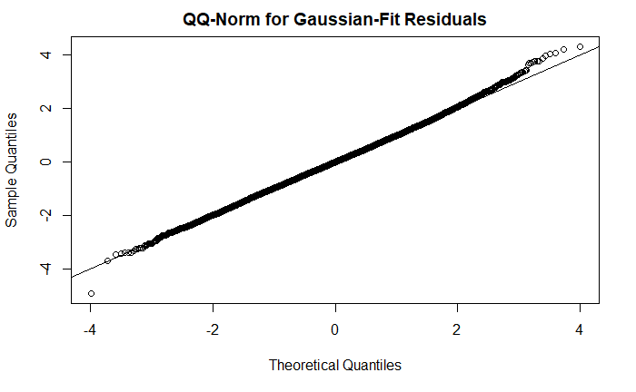

| RMSE | R2 | MAE |
| --- | --- | --- |
| 17.72 | 0.3689 | 14 |

Here are the weights as returned by the model.

| X1 | X3 | X6 | X7 | X8 | X11 |
| --- | --- | --- | --- | --- | --- |
| 0.3056 | 0.2659 | 0.07615 | 0.1217 | 0.07076 | 0.1599 |

Here are the unconstrained MLEs, which are interesting to compare to. Almost always, regardless of the outcome being modeled, the final AIC-selected combination of base learners just so happen to (almost) meet the non-negative and sum-to-one constraint just by themselves, for example,

| X1 | X3 | X6 | X7 | X8 | X11 |
| --- | --- | --- | --- | --- | --- |
| 0.2713 | 0.2415 | 0.09971 | 0.1313 | 0.09526 | 0.161 |

```
## [1] "Sum of unconstrained MLE weights: 1.00008969194015"
```

Below are traceplots for posterior draws of $\sigma^2$ and $\sigma^2_{\hat{\eta}}$ respectively from my most recent points-per-48-minutes model.

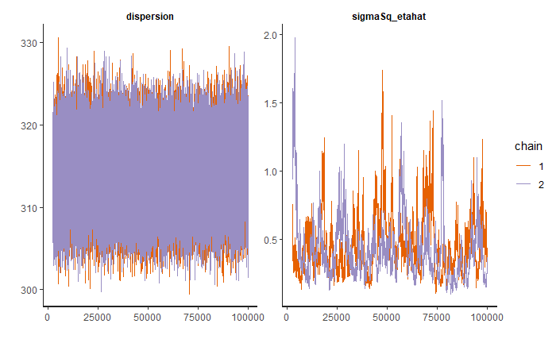

Even though the posterior draws of $\sigma^2_{\hat{\eta}}$ might look erratic, plotting the smoothed-density describes something we might reasonably expect from a gamma distribution, and as far as I’m concerned, reasonably quantifies my uncertainty of how my model’s prediction relates to the data-generating function I am interested in. I’m okay with it. As well, after doing this every day for weeks, I tend to get similar posterior draws every time, even with different priors.

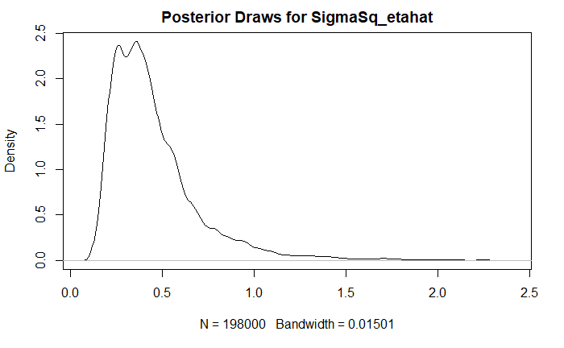

## Placing Bets

### Inputting Priors

The only actual daily physical task I need to do to place bets is to type in the over under set by Vegas and hit ctrl+enter. My R script will automatically webscrape NBA data from last-night’s games (or any previous games I missed), clean and process it, load my pre-trained models, make predictions on the new data, generate Metropolis-Hastings MCMC draws based on those predictions, and print out results telling me to whether to bet or not.

For example, on December 8th, here was the information I inputted from PointsBet.com to run my script.

It isn’t important, but I also record “spread” and “moneyline odds” given by PointsBet so I can derive a prior distribution for these outcomes in the future.

```r
if(F){
## enter matchups
#' 1) away team,
#' 2) home team,
#' 3) spread,
#' 4) over/under
#' 5) moneyline
matchups_enter <- matrix(

  c(  #HomeTeam, #AwayTeam, #Spread, #Total, #MoneylineTop,MoneyLineBottom
   "PHI","CHA",-6,215,-245,195,
   "CHI","CLE",3,212.5,130,-150,
   "NYK","IND",5,208,170,-216,
   "WAS","DET",-5,210,-216,170,
   "MIL","MIA",-6,217,-265,210,
   "OKC","TOR",7.5,206,255,-331,
   "UTA","MIN",-6.5,218,-270,215,
   "BKN","HOU",-3,223,-160,135,
   "DAL","MEM",3,219,130,-150,
   "DEN","NOP",-2,212.5,-131,110,
   "POR","GSW",14,216,775,-1226,
   "ORL","SAC",6.5,222.5,220,-281,
   "BOS","LAC",4,209.5,150,-180
  ),
  byrow = T,
  ncol = 6
)
playoffs <- F
}
```

Here is a screenshot from PointsBet.com that will sort of show you what I mean, and how I come up with these numbers. I’ve highlighted a box that gives the over/under for Chicago vs. Cleveland (-110 is the odds, meaning I have to bet 11 dollars to make back 10, 100/110 = .909, you get the point). The over/under is 213 so I can bet “Ov” = Over, or “Un” = Under. As you might notice (the numbers for the game I entered above are slightly different), the over/unders and spread change throughout the day, depending on how many people bet on either side.

[figure not shown]

PointsBet Website

### Final Bets

“Abs” refers to the model for the normal-mixture of points-per-48 minutes and overtime (the link function was on the “absolute” scale). “Log” refers to the quasi-Poisson model, as this was the link function used. “Predict Abs” and “Predict Log” are the raw predictions returned by my stacked model(s). The over/under is what was reported by Vegas. MAPs are the kernel-density estimated maximum a-posteriori predictions for the final total-sum-of-points.

```r
load('final_final_bets.RData')
colnames(final) <- c('Date', 'AwayTeam', 'HomeTeam', 'Bet', 'Predict Abs', 'Predict Log', 'Over/Under', 'MAP Abs', 'MAP Log', 'DateBet')
pander::pander(final[,-1])
```

Table continues below

| AwayTeam | HomeTeam | Bet | Predict Abs | Predict Log | Over/Under |
| --- | --- | --- | --- | --- | --- |
| PHI | CHA | don’t bet | 210.6 | 214.6 | 215 |
| CHI | CLE | don’t bet | 220.2 | 216.1 | 212.5 |
| NYK | IND | don’t bet | 215.6 | 214.7 | 208 |
| WAS | DET | don’t bet | 207.2 | 203.5 | 210 |
| MIL | MIA | don’t bet | 213 | 218.6 | 217 |
| OKC | TOR | don’t bet | 201 | 201.8 | 206 |
| UTA | MIN | don’t bet | 224 | 219.8 | 218 |
| BKN | HOU | bet under | 209.2 | 205.4 | 223 |
| DAL | MEM | bet under | 204 | 205.3 | 219 |
| DEN | NOP | don’t bet | 214.9 | 208.2 | 212.5 |
| POR | GSW | bet under | 198.4 | 206.6 | 216 |
| ORL | SAC | don’t bet | 216.4 | 216.6 | 222.5 |
| BOS | LAC | don’t bet | 205 | 208.3 | 209.5 |

| MAP Abs | MAP Log | DateBet |
| --- | --- | --- |
| 212.2 | 216.6 | 2021-12-08 |
| 217.8 | 213.8 | 2021-12-08 |
| 214.1 | 207.9 | 2021-12-08 |
| 209 | 211.3 | 2021-12-08 |
| 220.4 | 215.8 | 2021-12-08 |
| 208.9 | 207.4 | 2021-12-08 |
| 220.6 | 215.9 | 2021-12-08 |
| 213.1 | 221.2 | 2021-12-08 |
| 211.8 | 214.9 | 2021-12-08 |
| 215.6 | 213.5 | 2021-12-08 |
| 208.5 | 214.4 | 2021-12-08 |
| 221.5 | 222.1 | 2021-12-08 |
| 205.9 | 209.6 | 2021-12-08 |

Notice, there’s mostly no bets recommended. I got lucky here; many days, there’s no recommended bets at all, indicating that at least one of the models is in agreement with Vegas. While this isn’t very fun, it is encouraging; it would be highly concerning if we were getting radically different results from Vegas. As we’d expect, opportunities to place bets are rare, as our stacked models are for the most part, closely in agreement with Vegas.

### Checking Posterior-Predictives

For generating posterior draws, I use little more than the MH function we turned in for homework recently. Obviously there are a lot of moving parts, but I think showing this snippet might convince you that the burdensome notation betrays the simplicity of what’s actually happening.

This is for the points-per-48 minutes outcome.

```r
if(F){
######### Empirical smoothed-densities of posterior draws ##
  ## posterior draws of variance parameters
posterior_draws <- cbind(c(stan.result@sim$samples[[1]]$dispersion[-c(1:10000)],
                           stan.result@sim$samples[[2]]$dispersion[-c(1:10000)]),
                         c(stan.result@sim$samples[[1]]$sigmaSq_etahat[-c(1:10000)],
                           stan.result@sim$samples[[2]]$sigmaSq_etahat[-c(1:10000)]))

######### Distributions for new data #######################
  ## formulas for computing the joint posterior
closest_density <- function(v,dens){
  diff <- abs(dens[,1]-v)
  dens[,2][which(diff == min(diff))]/sum(dens[,2])
}
f_y_given_eta <- function(Y,eta,dispersion){
  sum((dnorm(Y,mean = eta, sd = sqrt(dispersion),log = T)))
}
f_etahat_given_y_eta_sigmaSqhateta <- f_y_given_eta
prior_eta <- function(eta,mu0,sigmaSq0){
  sum((dnorm(eta,mean = mu0*(48/48.324), sd = sqrt(sigmaSq0)*48/48.324,log = T)))
}
sigmaSq0 <- var(vegas_resid)*(48/avg_time)^2
density_sigmaSqetahat <- cbind(density(posterior_draws[,2])$x,
                               density(posterior_draws[,2])$y)
density_dispersion <- cbind(density(posterior_draws[,1])$x,
                            density(posterior_draws[,1])$y)
post_eta <- function(sigmaSq_0,
                     sigmaSq,
                     mu_0,
                     x_i,
                     eta){
  new_mu <- 1/(1/sigmaSq_0 + 1/sigmaSq) *
    (mu_0/sigmaSq_0 + x_i/sigmaSq)

  new_sig <- sqrt(
    1/(1/sigmaSq_0+ 1/sigmaSq)
  )

  dnorm(eta,mean = new_mu, sd = new_sig,log = T)
}
######### START MH for new data #############################
post_predictive_draws <- list()
for(k in 1:length(vegas_preds)){
  print(k)
  initial_values <- c("eta" = vegas_preds[k]*(48/avg_time),
                      "Ynew" = as.numeric((my_preds_per48[k])),

                      "dispersion" = sum(density_dispersion[,1]*density_dispersion[,2])/sum(density_dispersion[,2]),
                      "sigmaSq_etahat" = sum(density_sigmaSqetahat[,1]*density_sigmaSqetahat[,2])/sum(density_sigmaSqetahat[,2]))
  M <- initial_values
  result <- foreach(chain = 1:5,.combine = 'rbind') %do% {
    print("")
    res_temp <- try({(foreach(i = 1:48000,
             .combine = 'rbind') %dopar% {
               MM <- try({MH_update(
                 M,
                 f = function(x) {
                     log(closest_density(x['dispersion'],density_dispersion)) +
                     log(closest_density(x['sigmaSq_etahat'],density_sigmaSqetahat)) +
                     f_y_given_eta(x['Ynew'], x['eta'],x['dispersion']) +
                     post_eta(sigmaSq0,
                              x['sigmaSq_etahat']+x['dispersion'], ## we add dispersion when marginalizing over Y
                              vegas_preds[k],
                              my_preds_per48[k],
                              x['eta'])
                 },
                 g = function(from,to,sd_prop = c(4,10,2,1,1)){
                   sum(log(dnorm(to,from,sd_prop)))
                 },
                 g.s = function(from,sd_prop = c(4,10,2,1,1)){
                   from + rnorm(length(from),
                                0,
                                sd_prop)
                 },
                 log = T)},silent = T)
               if(class(MM) != 'try-error'){
                 Mprev <- M
                 M <- MM
                 if(any(M != Mprev)){
                   M
                 } else{
                   invisible()
                 }
               } else {
                 M <- M + rnorm(length(M),
                                0,
                                0.01)
               }
             })},silent = T)
    if(class(res_temp) != 'try-error'){
      ## burn-in the first 4th
      res_temp <- res_temp[-c(1:(nrow(res_temp)/4)),]
      ## only select every 2nd (thinning)
      res_temp[seq(1,nrow(res_temp),by = 2),]
    }
  }
  post_predictive_draws[[k]] <- result[,2]
  plot(post_predictive_draws[[k]],
       main = paste0("M.H. Draws for Total Points Scored per 48 Min: ",
                     paste(matchups_enter[k,1:2],collapse = " vs. "),
                                     collapse = ""))
}
stopCluster(cl)
######### END MH #############
}
```

Since we ended up betting under on DAL (Dallas Mavericks) vs. MEM (Memphis Grizzlies), let’s look at their posterior-predictive distributions generated by the Metropolis-Hastings (MH) algorithm and make sure they look reasonable.

#### Points per 48 Minutes (Linear Mixed-Effects Stacked Model)

Points-per-48 minutes looks good.

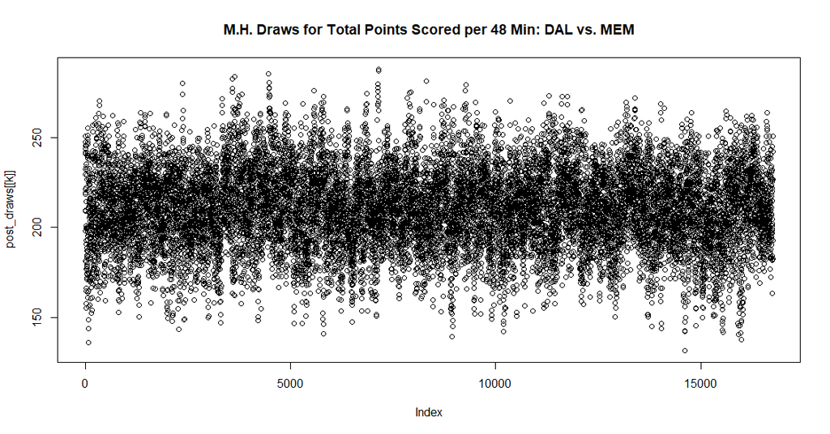

#### Overtime (Categorical Mixed-Effects Stacked Model)

Despite it looking like posterior-draws did not converge, overall, this looks good “enough” to me, considering typical overtime percentages range between these values (and overtime predictions affect my decision to bet very little).

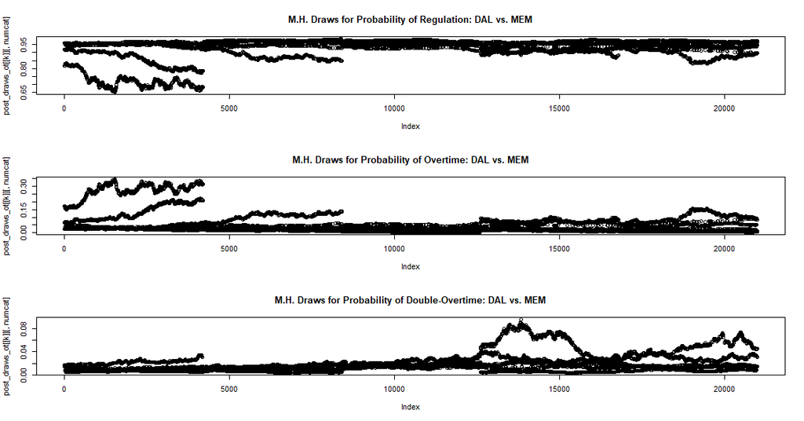

#### Total Points (Overdispersed-Poisson Mixed-Effects Stacked Model)

The quasi-poisson model posterior draws look excellent

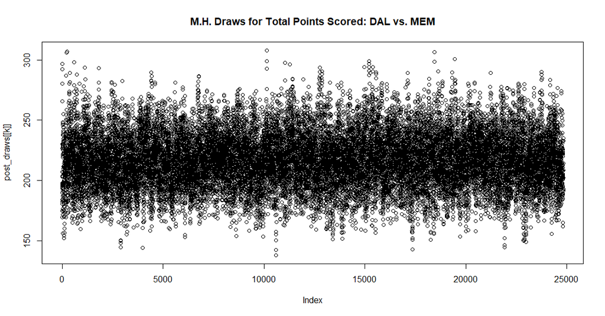

It turns out, the posterior-predictive distributions for both approaches were in agreement; at least 52.38% of the Metropolis-Hastings MCMC draws were $\textit{less}$ than the over/under reported by Vegas for BOTH the normal mixture and quasi-Poisson models; hence, placing a bet $\textit{under}$ was recommended. More detailed output (such as expected profit) and code for doing all of this is provided of course.

### Results

Let’s look to see how our bets and predictions fared.

Table continues below

| AwayTeam | HomeTeam | Bet | Predict Abs | Predict Log | Over/Under |
| --- | --- | --- | --- | --- | --- |
| PHI | CHA | don’t bet | 210.6 | 214.6 | 215 |
| CHI | CLE | don’t bet | 220.2 | 216.1 | 212.5 |
| NYK | IND | don’t bet | 215.6 | 214.7 | 208 |
| WAS | DET | don’t bet | 207.2 | 203.5 | 210 |
| MIL | MIA | don’t bet | 213 | 218.6 | 217 |
| OKC | TOR | don’t bet | 201 | 201.8 | 206 |
| UTA | MIN | don’t bet | 224 | 219.8 | 218 |
| BKN | HOU | bet under | 209.2 | 205.4 | 223 |
| DAL | MEM | bet under | 204 | 205.3 | 219 |
| DEN | NOP | don’t bet | 214.9 | 208.2 | 212.5 |
| POR | GSW | bet under | 198.4 | 206.6 | 216 |
| ORL | SAC | don’t bet | 216.4 | 216.6 | 222.5 |
| BOS | LAC | don’t bet | 205 | 208.3 | 209.5 |

| MAP Abs | MAP Log | DateBet | Actual Total Points | Result |
| --- | --- | --- | --- | --- |
| 212.2 | 216.6 | 2021-12-08 | 216 | No Bet Placed |
| 217.8 | 213.8 | 2021-12-08 | 207 | No Bet Placed |
| 214.1 | 207.9 | 2021-12-08 | 224 | No Bet Placed |
| 209 | 211.3 | 2021-12-08 | 235 | No Bet Placed |
| 220.4 | 215.8 | 2021-12-08 | 217 | No Bet Placed |
| 208.9 | 207.4 | 2021-12-08 | 219 | No Bet Placed |
| 220.6 | 215.9 | 2021-12-08 | 240 | No Bet Placed |
| 213.1 | 221.2 | 2021-12-08 | 218 | WIN |
| 211.8 | 214.9 | 2021-12-08 | 200 | WIN |
| 215.6 | 213.5 | 2021-12-08 | 234 | No Bet Placed |
| 208.5 | 214.4 | 2021-12-08 | 198 | WIN |
| 221.5 | 222.1 | 2021-12-08 | 272 | No Bet Placed |
| 205.9 | 209.6 | 2021-12-08 | 225 | No Bet Placed |

Great we won all of our bets. However, I got lucky; since December 1st when I recorded the companion video, I’m only 10/16. It’s profit, but I’m not getting rich anytime soon, and it’s a small sample size. Nevertheless, $\textit{I'm still out for blood}$.

Here is a screenshot of my earnings over the past week.

[figure not shown]

PointsBet Website

## Modeling Spread and Moneyline

Briefly, the spread is the difference in points between the home team and away team at the end of the game, and you can bet whether you think a team will win by more or less points than another team. The moneyline is just betting on who will win or lose. These are fun outcomes to model by themselves, but frankly I’m done modeling because spending time with my family and friends is more important. It also involves modeling a Skellam distribution https://en.wikipedia.org/wiki/Skellam_distribution, which isn’t easily incorporated into the AbsolutelyStacked pipeline. Fortunately, there is a shortcut.

I argue, once we have posterior draws for total points scored, we have everything we need to derive posterior-predictive distributions for spread and moneyline too.

Knowing the over/under and spread, we can easily reconstruct the total points that Vegas predicted the home team to score $(Y_{Home})$

$$Y_{Home} = \frac{(Y_{Home} - Y_{Away}) +(Y_{Home} + Y_{Away})}{2} \\ \hat{Y}_{Home}= \frac{(Spread) +(Over/Under)}{2} \\
\hat{\theta}_{Vegas} = \log(\frac{\frac{\hat{Y}_{Home}}{(\hat{Y}_{Home} + \hat{Y}_{Away})}}{1-\frac{\hat{Y}_{Home}}{(\hat{Y}_{Home} + \hat{Y}_{Away})}}) = \log(\hat{{Y}}_{Home})-\log(\hat{{Y}}_{Away})$$

Conveniently, Vegas’s residuals of the logit-proportion of home team points scored is again, well-approximated by normality.

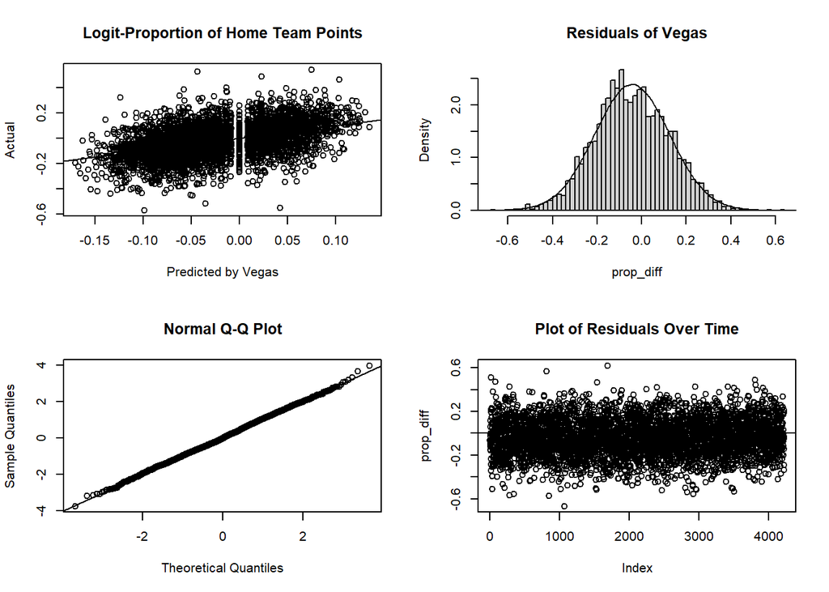

The posterior-predictive distribution for the spread is then straightforward to derive. We already have the marginal, posterior-predictive distribution for total points scored; and now we have a direct prior on the logit-proportion of points scored by the home team, conditional upon total points scored. Finally, we know that these are $\textit{orthogonal}$ outcomes (the sample size tells us nothing about the proportion, the proportion tells us nothing about the sample size), so they are independent. A simple 4-step algorithm provides us with posterior draws of the spread.

$$1) \text{ Sample } Y^{New} \text{ from } P(Y^{New}|\cdot) \text{ the posterior-predictive distribution of total points} \\
2) \text{ Sample } \theta^{New} \text{ from } P(\theta^{New}) \sim N(\hat{\theta}^{New}_{Vegas},\sigma_{\hat{\theta}_{Vegas}}) \\
3) \text{ Compute } Y^{New}_{Home} = (\frac{e^{\theta^{New}}}{1+e^{\theta^{New}}})*Y^{New} \\
4) \text{ Compute } Y^{New}_{Home}-Y^{New}_{Away} = 2Y^{New}_{Home}-Y^{New}$$

Obviously, if we have a posterior-predictive distribution for the difference in points between the home team and away team, we immediately have a posterior-predictive distribution for the probability of the home team winning or losing, and so we can place informed moneyline bets as well. The point is, once we have total points modeled, we can make all 3 types of the most popular bets rather than having to re-model everything from scratch.

# Conclusion

## Interpretation

A key philosophy that makes this all possible (or not possible, if you disagree) is the strong likelihood principle; the belief that all of the information in a sample is communicated by its likelihood.

A proof presented by Dr. Breheny on the first day of Likelihood Theory gives some mathematical insight into why people might think this; https://myweb.uiowa.edu/pbreheny/7110/wiki/likelihood-is-minimal-sufficient.html.

If you subscribe to the strong likelihood principle, then you don’t need to know anything about the training data other than it’s likelihood, as this contains “all” of the information in the sample. Whether or not the model is tractable (a stacked model certainly isn’t), the likelihood doesn’t care; all that is needed to compute the likelihood are the observed values, the fitted values, and if relevant, the exponential dispersion parameter. Maybe it isn’t easily interpretable or tractable, but depending on your task, that might not matter. Once we have the likelihood, we can use information-theoretic AIC backwards selection to choose the best combination of base learners, a permuted likelihood-ratio statistic for evaluating variable importance, and Bayesian posterior-predictive distributions for making decisions. As long as we can partition really complicated or difficult-to-model outcomes into its orthogonal sub-components (for example, a Skellam distribution with correlated outcomes into a normal GLM for total-points-per-48 minutes, a categorical GLM for number of minutes, and a binomial GLM for proportion-of-points-scored by home team), we can use the stacked likelihood to glue it all back together with $\textit{no loss of information}$, using whatever big-black-box models and fancy normalization schemes we desire.

One way stacking can then be interpreted is from the perspective of feature reduction; once trained, out-of-fold predictions of base learners are deterministic functions that map from higher-dimensions into single vectors of predictions (matrices for categorical outcomes), predictions that when link-function transformed, are well approximated by a linear-relationship with the outcome of interest, making it easy for a GLM to model (and easy for us to compute the likelihood). Since all of the information in the sample is communicated through the likelihood, $\textit{philosphically}$ speaking, there’s no actual loss-of-information happening when we stack, and so all of that complicated nasty non-linear happenings in the data can still be explained with the same GLM models we statisticians prefer, all captured by just a $\textit{few parsimonious covariates}$, i.e., the base-learner predictions.

Another way stacking can be interpreted is from a Bayesian perspective; note that on the simulations, we sometimes achieved marginally better performance with the constrained coefficients than the unconstrained….. not that the unconstrained MLEs didn’t perform well, just that $\textit{knowing ahead of time}$ the lower bounds and sum of the coefficients obviously helped the constrained MLEs achieve better estimates.

Hence, the sum-to-one and non-negativity constraint is simply an improper prior; and that’s why we find the unconstrained MLEs first, and why finding the constrained weights is referred to as $\textit{updating}$. The MLE weights are sufficient for capturing the out-of-fold likelihood, the prior distribution is the constraint, so the constrained weights are actually MAP estimates.

$$P(\beta|\hat{\beta}_{MLE}) \propto P(\hat{\beta}_{MLE}|\beta)P(\beta) \\
P(\beta) \sim 1_{\sum^p_j {\beta_j} = 1, \beta_j \geq 0 \forall j}$$

This helps illustrate the connection to penalized regression as well; consider, as we saw, the weights tend to be non-negative anyways when we have a parsimonious set of base-learners, so this constraint is easily satisfied. The only constraint left is the sum-to-one, which is equivalently formulated as follows.

$$P(\beta) \sim 1_{\sum^p_j {\beta_j} = 1} \equiv P(\beta) \sim 1_{\sum^p_j { |\beta_j |} = 1}$$

This accomplishes the same task as LASSO; except instead of using cross-validation to find the penalty term or a more direct approach, we are simply defining it explicitly to be whatever happens to satisfy the sum-to-one constraint (you can confirm this by looking at the Lagrangian terms returned by quadprog and Rsolnp as well).

As was shown theoretically and empirically, we have a lot of good reasons to think that this prior distribution (the sum-to-one and non-negativity constraint) holds true. By far the most common procedure on Kaggle and the literature for selecting weights is using LASSO as the meta-learner, tuned with cross-validation (which requires nested cross-validation). At the very least, the approach presented here suggests this is unnecessary; we already have a pretty good idea of what the penalty should be, and it’s whatever happens to satisfy the sum-to-one constraint.

Because I’ve included an l2-norm penalty term as well, you can technically use AbsolutelyStacked to fit the equivalent-of elastic-net models (under the very special circumstance that the coefficients are all of the same sign) although I wouldn’t particularly recommend it as the easiest option for doing so; tuning would be performed for the l2-norm penalty and the sum constraint (which implies a certain l1-penalty).

Apparently, you can use quadratic programming to fit proper l1-norm regularized models as well https://www.erikdrysdale.com/l1_solution/.

## Final Thoughts

It may seem like a lot, but I sincerely believe I did about the bare minimum of what I needed to do in order to obtain a valid method of betting on NBA games that was actually powerful enough to $\textit{sometimes}$ allow me to make bets.

If I have learned anything from this project, it is that being a good subjective Bayesian is like being a good partner in a relationship; it requires honesty, trust, being sensitive to different viewpoints, and paying attention to the little things, even when it gets complicated. As well, model-averaging is mathematical proof that bringing together a diversity of different ideas will improve predictive performance while echo chambers, with high-covariance between base learners, will prove otherwise.

Thank you so much for reading, it honestly means the world to me if (somehow) you got this far

Matt

# Bibliography

## Notable Packages

Smith BJ (2021). *MachineShop: Machine Learning Models and Tools*. R package version 3.1.0.9001, <URL: https://cran.r-project.org/package=MachineShop>

S original by Berwin A. Turlach R port by Andreas Weingessel Andreas.Weingessel@ci.tuwien.ac.at Fortran contributions from Cleve Moler dpodi/LINPACK) (2019). quadprog: Functions to Solve Quadratic Programming Problems. R package version 1.5-8. https://CRAN.R-project.org/package=quadprog

Alexios Ghalanos and Stefan Theussl (2015). Rsolnp: General Non-linear Optimization Using Augmented Lagrange Multiplier Method. R package version 1.16.

Douglas Bates and Martin Maechler (2021). Matrix: Sparse and Dense Matrix Classes and Methods. R package version 1.3-4. https://CRAN.R-project.org/package=Matrix

Alex Bresler (2021). nbastatR: R’s interface to NBA data. R package version 0.1.151. https://github.com/abresler/nbastatR

## Works Cited and Futher Reading

Wolpert, D. H. (1992). Stacked generalization. 5(2), 241–259.

Fisher, A., Rudin, C., and Dominici, F. (2018). All models are wrong, but many are useful: Learning a variable’s importance by studying an entire class of prediction models simultaneously.

Li, X.-m., Zou, G.-h., Zhang, X.-y., and Zhao, S.-w. (2021). Least squares model averaging based on generalized cross validation. 37(3), 495–509.

Ando, T. and Li, K.-C. (2014). A model-averaging approach for high-dimensional regression. 109(505), 254–265. Publisher: Taylor & Francis eprint: https://doi.org/10.1080/01621459.2013.838168.

Ando, T. and Li, K.-c. (2017). A weight-relaxed model averaging approach for high-dimensional generalized linear models. 45(6), 2654–2679. Publisher: Institute of Mathematical Statistics.

Zhang, H. and Zou, G. 2020). Cross-validation model averaging for generalized functional linear model. 8(1), 7. Number: 1 Publisher: Multidisciplinary Digital Publishing Institute.

Golmakani, M. K. and Polley, E. C. (2020). Super learner for survival data prediction. 16(2). Publisher: De Gruyter.

Breiman, L. (1996). Stacked regressions. 24(1), 49–64.

Leblanc, M. and Tibshirani, R. (1996). Combining estimates in regression and classification. 91(436), 1641–1650. Publisher: Taylor & Francis eprint: https://doi.org/10.1080/01621459.1996.1047673

Charkhi, A., Claeskens, G., and Hansen, B. E. (2016). Minimum mean squared error model averaging in likelihood models.

Clarke, B. (2003). Comparing bayes model averaging and stacking when model approximation error cannot be ignored. 4, 683–712.

Laan, M. J. v. d., Polley, E. C., and Hubbard, A. E. (2007). Super learner. 6(1). Publisher: De Gruyter.

Le, T. and Clarke, B. (2017). A bayes interpretation of stacking for m-complete and m-open settings. 12(3), 807–829. Publisher: International Society for Bayesian Analysis.

Dormann, C. F., Calabrese, J. M., Guillera-Arroita, G., Matechou, E., Bahn, V., Barto ́n, K., Beale, C. M., Ciuti, S., Elith, J., Gerstner, K., Guelat, J., Keil, P., Lahoz-Monfort, J. J., Pollock, L. J., Reineking, B., Roberts, D. R., Schr ̈oder, B., Thuiller, W., Warton, D. I., Wintle, B. A., Wood, S. N., W ̈uest, R. O., and Hartig, F. (2018). Model averaging in ecology: a review of bayesian, information-theoretic, and tactical approaches for predictive inference. 88(4), 485–504. eprint: https://onlinelibrary.wiley.com/doi/pdf/10.1002/ecm.1309.

Fang, Yixin (2011), “Asymptotic equivalence between cross-validations and Akaike Information Criteria in mixed-effects models” (PDF), Journal of Data Science, 9: 15–21.

Stone, M. (1977), “An asymptotic equivalence of choice of model by cross-validation and Akaike’s criterion”, Journal of the Royal Statistical Society, Series B, 39 (1): 44–47, doi:10.1111/j.2517-6161.1977.tb01603.x, JSTOR 2984877.